[figure not shown]

# MBD-PT 2023 Social Network Analysis

## Analysing Drug Interactions and Chemical Compound Similarities for Business Insights - Graph Metrics

[figure not shown]

# **3. CHEMICAL SIMILARITY GRAPH FOR AIDED DRUG DISCOVERY TO PREDICT ATC AND MAJOR INTERACTIONS OF NEW MOLECULES**

# **3.0 IMPORT REQUIRED LIBRARIES**

```python
import igraph as ig
import pandas as pd
import numpy as np
import matplotlib.pyplot as plt
```

# **3.1 IMPORT EDGES DATA FROM DDINTER**

- Here the edges file created in the first notebook is loaded.
- The source is ddinter (http://ddinter.scbdd.com/download/)

```python
#convert combined_df to csv file with ";" as separator
edges_df = pd.read_csv(r'C:\Users\Javier\IE Students\Term 3 - Data Dynamos - Documentos\General\Social Network Analysis\drugs\chemical_interaction_FINAL\edges.csv', sep=';')[['DDInterID_A','Drug_A','DDInterID_B','Drug_B','Level']]

# In this case the weight is set from Major = 3 and Minor = 1 as we will just use Degree and at most Strength for
# chemical similarity network

edges_df['Weight'] = edges_df.apply(lambda x: 3 if x['Level']=='Major'
                                    else (1 if x['Level']=='Minor' else 2), axis=1)

edges_df
```

|  | DDInterID_A | Drug_A | DDInterID_B | Drug_B | Level | Weight |
| --- | --- | --- | --- | --- | --- | --- |
| 0 | DDInter513 | Dexamethasone | DDInter582 | Dolutegravir | Minor | 1 |
| 1 | DDInter997 | Ivacaftor | DDInter582 | Dolutegravir | Minor | 1 |
| 2 | DDInter1019 | Lamivudine | DDInter1123 | Mannitol | Moderate | 2 |
| 3 | DDInter195 | Betamethasone | DDInter1961 | Zidovudine | Moderate | 2 |
| 4 | DDInter1961 | Zidovudine | DDInter246 | Budesonide | Moderate | 2 |
| ... | ... | ... | ... | ... | ... | ... |
| 160230 | DDInter856 | Heparin | DDInter805 | gamma-Aminobutyric acid | Unknown | 2 |
| 160231 | DDInter1683 | Sodium bicarbonate | DDInter805 | gamma-Aminobutyric acid | Unknown | 2 |
| 160232 | DDInter908 | Iloprost | DDInter62 | Ambrisentan | Unknown | 2 |
| 160233 | DDInter1951 | Warfarin | DDInter1942 | Vitamin D | Unknown | 2 |
| 160234 | DDInter1683 | Sodium bicarbonate | DDInter1942 | Vitamin D | Unknown | 2 |

160235 rows × 6 columns

- Now checking the amount of interactions of each category

```python
edges_df[edges_df['Level']=='Minor']['Weight'].value_counts()
```

```
1    6833
Name: Weight, dtype: int64
```

```python
edges_df[edges_df['Level']=='Moderate']['Weight'].value_counts()
```

```
2    96675
Name: Weight, dtype: int64
```

```python
edges_df[edges_df['Level']=='Major']['Weight'].value_counts()
```

```
3    26914
Name: Weight, dtype: int64
```

```python
edges_df[edges_df['Level']=='Unknown']['Weight'].value_counts()
```

```
2    29813
Name: Weight, dtype: int64
```

# **3.2 IMPORT NODES DATA**

- Here the nodes file created in the first notebook is loaded.
- The main source of extra information used in this notebook is chembl for the ATCs, and type of administration

```python
nodes_df = pd.read_csv(r'C:\Users\Javier\IE Students\Term 3 - Data Dynamos - Documentos\General\Social Network Analysis\drugs\chemical_interaction_FINAL\nodes_simplified.csv', sep=';')
nodes_df = nodes_df.fillna(0)
nodes_df
```

|  | DDInterID | Drug | Drug_original | topical | nasal | ophthalmic | oral | parenteral | indication_class | chirality | ... | V09_-_DIAGNOSTIC_RADIOPHARMACEUTICALS | H03_-_THYROID_THERAPY | B03_-_ANTIANEMIC_PREPARATIONS | D09_-_MEDICATED_DRESSINGS | D03_-_PREPARATIONS_FOR_TREATMENT_OF_WOUNDS_AND_ULCERS | D02_-_EMOLLIENTS_AND_PROTECTIVES | J07_-_VACCINES | A09_-_DIGESTIVES,_INCL._ENZYMES | V06_-_GENERAL_NUTRIENTS | H04_-_PANCREATIC_HORMONES |
| --- | --- | --- | --- | --- | --- | --- | --- | --- | --- | --- | --- | --- | --- | --- | --- | --- | --- | --- | --- | --- | --- |
| 0 | DDInter513 | Dexamethasone | Dexamethasone | True | False | False | True | True | Glucocorticoid | 1.0 | ... | 0 | 0 | 0 | 0 | 0 | 0 | 0 | 0 | 0 | 0 |
| 1 | DDInter997 | Ivacaftor | Ivacaftor | False | False | False | True | 0 | 0 | 2.0 | ... | 0 | 0 | 0 | 0 | 0 | 0 | 0 | 0 | 0 | 0 |
| 2 | DDInter1019 | Lamivudine | Lamivudine | False | False | False | True | 0 | Antiviral | 1.0 | ... | 0 | 0 | 0 | 0 | 0 | 0 | 0 | 0 | 0 | 0 |
| 3 | DDInter195 | Betamethasone | Betamethasone | True | False | False | True | 0 | Glucocorticoid | 1.0 | ... | 0 | 0 | 0 | 0 | 0 | 0 | 0 | 0 | 0 | 0 |
| 4 | DDInter1961 | Zidovudine | Zidovudine | False | False | False | True | True | Antiviral | 1.0 | ... | 0 | 0 | 0 | 0 | 0 | 0 | 0 | 0 | 0 | 0 |
| ... | ... | ... | ... | ... | ... | ... | ... | ... | ... | ... | ... | ... | ... | ... | ... | ... | ... | ... | ... | ... | ... |
| 1934 | DDInter371 | Chondroitin sulfate | Chondroitin sulfate | False | False | False | 0 | 0 | 0 | 1.0 | ... | 0 | 0 | 0 | 0 | 0 | 0 | 0 | 0 | 0 | 0 |
| 1935 | DDInter446 | Cranberry | Cranberry | False | False | False | 0 | 0 | 0 | 0.0 | ... | 0 | 0 | 0 | 0 | 0 | 0 | 0 | 0 | 0 | 0 |
| 1936 | DDInter829 | Glucosamine | Glucosamine | False | False | False | 0 | 0 | 0 | 1.0 | ... | 0 | 0 | 0 | 0 | 0 | 0 | 0 | 0 | 0 | 0 |
| 1937 | DDInter1390 | Papaya | Papaya | False | False | False | 0 | 0 | 0 | 0.0 | ... | 0 | 0 | 0 | 0 | 0 | 0 | 0 | 0 | 0 | 0 |
| 1938 | DDInter1551 | Pyrophosphoric acid | Pyrophosphoric acid | False | False | False | 0 | 0 | 0 | 0.0 | ... | 0 | 0 | 0 | 0 | 0 | 0 | 0 | 0 | 0 | 0 |

1939 rows × 118 columns

# **3.3 CHEMICAL STRUCTURE: SMILES**

- Now the nodes with chemical structure as string (canonical SMILES representation) is uploaded
- This file has been generated before with a differnet specific notebook.
- For its generation we have used chembl API (https://github.com/chembl/chembl_webresource_client)
- After importing, it is merged with the just uploaded nodes dataframe.
- This way, the "nodes_smiles_df" is now a big dataframe that contains not only the previous node information but also now the SMILES chemical represetnation

```python
nodes_smiles = pd.read_csv('nodes_with_smiles_no_index.csv')
nodes_smiles = nodes_smiles[nodes_smiles['smiles']!='None']
nodes_smiles_df = nodes_smiles.merge(nodes_df, left_on='molecule', right_on='Drug', how='inner')
nodes_smiles_df
```

|  | molecule | smiles | DDInterID | Drug | Drug_original | topical | nasal | ophthalmic | oral | parenteral | ... | V09_-_DIAGNOSTIC_RADIOPHARMACEUTICALS | H03_-_THYROID_THERAPY | B03_-_ANTIANEMIC_PREPARATIONS | D09_-_MEDICATED_DRESSINGS | D03_-_PREPARATIONS_FOR_TREATMENT_OF_WOUNDS_AND_ULCERS | D02_-_EMOLLIENTS_AND_PROTECTIVES | J07_-_VACCINES | A09_-_DIGESTIVES,_INCL._ENZYMES | V06_-_GENERAL_NUTRIENTS | H04_-_PANCREATIC_HORMONES |
| --- | --- | --- | --- | --- | --- | --- | --- | --- | --- | --- | --- | --- | --- | --- | --- | --- | --- | --- | --- | --- | --- |
| 0 | Dexamethasone | C[C@@H]1C[C@H]2[C@@H]3CCC4=CC(=O)C=C[C@]4(C)[C... | DDInter513 | Dexamethasone | Dexamethasone | True | False | False | True | True | ... | 0 | 0 | 0 | 0 | 0 | 0 | 0 | 0 | 0 | 0 |
| 1 | Ivacaftor | CC(C)(C)c1cc(C(C)(C)C)c(NC(=O)c2c[nH]c3ccccc3c... | DDInter997 | Ivacaftor | Ivacaftor | False | False | False | True | 0 | ... | 0 | 0 | 0 | 0 | 0 | 0 | 0 | 0 | 0 | 0 |
| 2 | Lamivudine | Nc1ccn([C@@H]2CS[C@H](CO)O2)c(=O)n1 | DDInter1019 | Lamivudine | Lamivudine | False | False | False | True | 0 | ... | 0 | 0 | 0 | 0 | 0 | 0 | 0 | 0 | 0 | 0 |
| 3 | Betamethasone | C[C@H]1C[C@H]2[C@@H]3CCC4=CC(=O)C=C[C@]4(C)[C@... | DDInter195 | Betamethasone | Betamethasone | True | False | False | True | 0 | ... | 0 | 0 | 0 | 0 | 0 | 0 | 0 | 0 | 0 | 0 |
| 4 | Zidovudine | Cc1cn([C@H]2C[C@H](N=[N+]=[N-])[C@@H](CO)O2)c(... | DDInter1961 | Zidovudine | Zidovudine | False | False | False | True | True | ... | 0 | 0 | 0 | 0 | 0 | 0 | 0 | 0 | 0 | 0 |
| ... | ... | ... | ... | ... | ... | ... | ... | ... | ... | ... | ... | ... | ... | ... | ... | ... | ... | ... | ... | ... | ... |
| 1327 | Simethicone | CC(C)(C)[SiH2]O[Si](C)(C)O[SiH2]C(C)(C)C | DDInter1674 | Simethicone | Simethicone | False | False | False | True | 0 | ... | 0 | 0 | 0 | 0 | 0 | 0 | 0 | 0 | 0 | 0 |
| 1328 | Icatibant | N=C(N)NCCC[C@@H](N)C(=O)N[C@@H](CCCNC(=N)N)C(=... | DDInter902 | Icatibant | Icatibant | False | False | False | 0 | True | ... | 0 | 0 | 0 | 0 | 0 | 0 | 0 | 0 | 0 | 0 |
| 1329 | Chondroitin sulfate | CC(=O)N[C@@H]1[C@@H](COC[C@@H]2O[C@H](C(=O)O)[... | DDInter371 | Chondroitin sulfate | Chondroitin sulfate | False | False | False | 0 | 0 | ... | 0 | 0 | 0 | 0 | 0 | 0 | 0 | 0 | 0 | 0 |
| 1330 | Glucosamine | N[C@H]1C(O)O[C@H](CO)[C@@H](O)[C@@H]1O | DDInter829 | Glucosamine | Glucosamine | False | False | False | 0 | 0 | ... | 0 | 0 | 0 | 0 | 0 | 0 | 0 | 0 | 0 | 0 |
| 1331 | Pyrophosphoric acid | O=P(O)(O)OP(=O)(O)O | DDInter1551 | Pyrophosphoric acid | Pyrophosphoric acid | False | False | False | 0 | 0 | ... | 0 | 0 | 0 | 0 | 0 | 0 | 0 | 0 | 0 | 0 |

1332 rows × 120 columns

```python
list(nodes_smiles_df.columns)
```

```
['molecule',
 'smiles',
 'DDInterID',
 'Drug',
 'Drug_original',
 'topical',
 'nasal',
 'ophthalmic',
 'oral',
 'parenteral',
 'indication_class',
 'chirality',
 'black_box_warning',
 'availability_type',
 'first_in_class',
 'ATC_Classifications',
 'ATC1_names',
 'SENSORY_ORGANS',
 'DERMATOLOGICALS',
 'SYSTEMIC_HORMONAL_PREPARATIONS,_EXCL._SEX_HORMONES_AND_INSULINS',
 'RESPIRATORY_SYSTEM',
 'ANTIPARASITIC_PRODUCTS,_INSECTICIDES_AND_REPELLENTS',
 'CARDIOVASCULAR_SYSTEM',
 'ALIMENTARY_TRACT_AND_METABOLISM',
 'GENITO_URINARY_SYSTEM_AND_SEX_HORMONES',
 'ANTIINFECTIVES_FOR_SYSTEMIC_USE',
 'BLOOD_AND_BLOOD_FORMING_ORGANS',
 'NERVOUS_SYSTEM',
 'MUSCULO-SKELETAL_SYSTEM',
 'VARIOUS',
 'ANTINEOPLASTIC_AND_IMMUNOMODULATING_AGENTS',
 'ATC2_names',
 'R01_-_NASAL_PREPARATIONS',
 'A01_-_STOMATOLOGICAL_PREPARATIONS',
 'S02_-_OTOLOGICALS',
 'S03_-_OPHTHALMOLOGICAL_AND_OTOLOGICAL_PREPARATIONS',
 'D07_-_CORTICOSTEROIDS,_DERMATOLOGICAL_PREPARATIONS',
 'D10_-_ANTI-ACNE_PREPARATIONS',
 'S01_-_OPHTHALMOLOGICALS',
 'C05_-_VASOPROTECTIVES',
```

[output cut: 65 more lines]

```
 'B06_-_OTHER_HEMATOLOGICAL_AGENTS',
 'A14_-_ANABOLIC_AGENTS_FOR_SYSTEMIC_USE',
 'P02_-_ANTHELMINTICS',
 'H05_-_CALCIUM_HOMEOSTASIS',
 'A05_-_BILE_AND_LIVER_THERAPY',
 'V09_-_DIAGNOSTIC_RADIOPHARMACEUTICALS',
 'H03_-_THYROID_THERAPY',
 'B03_-_ANTIANEMIC_PREPARATIONS',
 'D09_-_MEDICATED_DRESSINGS',
 'D03_-_PREPARATIONS_FOR_TREATMENT_OF_WOUNDS_AND_ULCERS',
 'D02_-_EMOLLIENTS_AND_PROTECTIVES',
 'J07_-_VACCINES',
 'A09_-_DIGESTIVES,_INCL._ENZYMES',
 'V06_-_GENERAL_NUTRIENTS',
 'H04_-_PANCREATIC_HORMONES']
```

# **3.4 PREPARE INTERACTION EDGES**

- Here a copy of the original dataframe is created for further use below.

```python
nodes_list_chem_sim = list(nodes_smiles_df['molecule'])
nodes_list_chem_sim[0:5]
```

```
['Dexamethasone', 'Ivacaftor', 'Lamivudine', 'Betamethasone', 'Zidovudine']
```

```python
edges_df_sim = edges_df.copy()
#edges_df_sim['select'] = edges_df.apply(lambda x: (x['Drug_A'] in nodes_list_chem_sim)&
#                        (x['Drug_B'] in nodes_list_chem_sim), axis=1)
#edges_df_sim = edges_df_sim[edges_df_sim['select']==True]
edges_df_sim
```

|  | DDInterID_A | Drug_A | DDInterID_B | Drug_B | Level | Weight |
| --- | --- | --- | --- | --- | --- | --- |
| 0 | DDInter513 | Dexamethasone | DDInter582 | Dolutegravir | Minor | 1 |
| 1 | DDInter997 | Ivacaftor | DDInter582 | Dolutegravir | Minor | 1 |
| 2 | DDInter1019 | Lamivudine | DDInter1123 | Mannitol | Moderate | 2 |
| 3 | DDInter195 | Betamethasone | DDInter1961 | Zidovudine | Moderate | 2 |
| 4 | DDInter1961 | Zidovudine | DDInter246 | Budesonide | Moderate | 2 |
| ... | ... | ... | ... | ... | ... | ... |
| 160230 | DDInter856 | Heparin | DDInter805 | gamma-Aminobutyric acid | Unknown | 2 |
| 160231 | DDInter1683 | Sodium bicarbonate | DDInter805 | gamma-Aminobutyric acid | Unknown | 2 |
| 160232 | DDInter908 | Iloprost | DDInter62 | Ambrisentan | Unknown | 2 |
| 160233 | DDInter1951 | Warfarin | DDInter1942 | Vitamin D | Unknown | 2 |
| 160234 | DDInter1683 | Sodium bicarbonate | DDInter1942 | Vitamin D | Unknown | 2 |

160235 rows × 6 columns

# **3.5 CALCULATE CHEMICAL SIMILARITIES**

- Based on all the SMILES chemical representations, in another notebook excluded from here for simplification purposes (note that the file created that contains all the required data is 0.3 GB), the Tanimoto chemical similarities based on 6 different fingerprints (FCFP4, BPF, BTD, PATH, AP, ECFP4) are calculated. The way it is calculated is based on functions provided within the GuacaMol library (https://github.com/BenevolentAI/guacamol)
- Note that the way to calculate the similarities based on SMILES is explained below for prediction purposes
- Also the product of all the 6 fingerprint-based Tanimoto similarities is calculated. This will be used later on for filtering using a threshold (to be explained later).

```python
chem_sim = pd.read_csv(r'C:\Users\Javier\IE Students\Term 3 - Data Dynamos - Documentos\General\Social Network Analysis\drugs\Javier\final\FINAL_EDGES_SIMILARITY_vF.csv')
chem_sim['chem_sim_PROD'] = chem_sim['FCFP4_tanimoto_sim'] * chem_sim['BPF_tanimoto_sim'] * chem_sim['BTF_tanimoto_sim'] \
                         * chem_sim['PATH_tanimoto_sim'] * chem_sim['AP_tanimoto_sim'] * chem_sim['ECFP4_tanimoto_sim']
chem_sim['chem_sim_PROD'] = chem_sim['chem_sim_PROD'] / (np.max(chem_sim['chem_sim_PROD']))

chem_sim = chem_sim.drop("Unnamed: 0", axis=1)
chem_sim
```

|  | drug_name_A | drug_name_B | smiles_A | smiles_B | ddinter_code_A | smiles_B.1 | ddinter_code_B | FCFP4_tanimoto_sim | BPF_tanimoto_sim | BTF_tanimoto_sim | PATH_tanimoto_sim | AP_tanimoto_sim | ECFP4_tanimoto_sim | chem_sim_PROD |
| --- | --- | --- | --- | --- | --- | --- | --- | --- | --- | --- | --- | --- | --- | --- |
| 0 | Tedizolid | Amobarbital | Cn1nnc(-c2ccc(-c3ccc(N4C[C@H](CO)OC4=O)cc3F)cn... | CCC1(CCC(C)C)C(=O)NC(=O)NC1=O | DDInter1752 | CCC1(CCC(C)C)C(=O)NC(=O)NC1=O | DDInter81 | 0.091743 | 0.157248 | 0.115385 | 0.162574 | 0.044444 | 0.062500 | 7.517195e-07 |
| 1 | Trioxsalen | Pimecrolimus | Cc1cc2cc3c(C)cc(=O)oc3c(C)c2o1 | CC[C@@H]1/C=C(\C)C[C@H](C)C[C@H](OC)[C@H]2O[C@... | DDInter1877 | CC[C@@H]1/C=C(\C)C[C@H](C)C[C@H](OC)[C@H]2O[C@... | DDInter1468 | 0.020513 | 0.086196 | 0.195312 | 0.234818 | 0.038929 | 0.075676 | 2.388948e-07 |
| 2 | Linagliptin | Telotristat ethyl | CC#CCn1c(N2CCC[C@@H](N)C2)nc2c1c(=O)n(Cc1nc(C)... | CCOC(=O)[C@@H](N)Cc1ccc(-c2cc(O[C@H](c3ccc(Cl)... | DDInter1070 | CCOC(=O)[C@@H](N)Cc1ccc(-c2cc(O[C@H](c3ccc(Cl)... | DDInter1760 | 0.242604 | 0.393110 | 0.284553 | 0.527853 | 0.178155 | 0.153846 | 3.926194e-04 |
| 3 | Argatroban | Telbivudine | CC1CNc2c(cccc2S(=O)(=O)N[C@@H](CCCNC(=N)N)C(=O... | Cc1cn([C@@H]2C[C@@H](O)[C@H](CO)O2)c(=O)[nH]c1=O | DDInter117 | Cc1cn([C@@H]2C[C@@H](O)[C@H](CO)O2)c(=O)[nH]c1=O | DDInter1757 | 0.126984 | 0.124615 | 0.149425 | 0.329435 | 0.093443 | 0.126984 | 9.242916e-06 |
| 4 | Bethanechol | Methenamine | CC(C[N+](C)(C)C)OC(N)=O | C1N2CN3CN1CN(C2)C3 | DDInter199 | C1N2CN3CN1CN(C2)C3 | DDInter1169 | 0.117647 | 0.176471 | 0.000000 | 0.049689 | 0.000000 | 0.000000 | 0.000000e+00 |
| ... | ... | ... | ... | ... | ... | ... | ... | ... | ... | ... | ... | ... | ... | ... |
| 886441 | Cisapride | Histrelin | COc1cc(N)c(Cl)cc1C(=O)NC1CCN(CCCOc2ccc(F)cc2)C... | CCNC(=O)[C@@H]1CCCN1C(=O)[C@H](CCCNC(=N)N)NC(=... | DDInter385 | CCNC(=O)[C@@H]1CCCN1C(=O)[C@H](CCCNC(=N)N)NC(=... | DDInter864 | 0.124611 | 0.103230 | 0.169154 | 0.367839 | 0.104387 | 0.107362 | 8.970139e-06 |
| 886442 | Cisatracurium | Nitisinone | COc1ccc(C[C@@H]2c3cc(OC)c(OC)cc3CC[N@+]2(C)CCC... | O=C1CCCC(=O)C1C(=O)c1ccc(C(F)(F)F)cc1[N+](=O)[O-] | DDInter386 | O=C1CCCC(=O)C1C(=O)c1ccc(C(F)(F)F)cc1[N+](=O)[O-] | DDInter1300 | 0.152074 | 0.096573 | 0.152866 | 0.273667 | 0.073625 | 0.091703 | 4.148130e-06 |
| 886443 | Paclitaxel | Norepinephrine | CC(=O)O[C@H]1C(=O)[C@@]2(C)[C@H]([C@H](OC(=O)c... | NC[C@H](O)c1ccc(O)c(O)c1 | DDInter1377 | NC[C@H](O)c1ccc(O)c(O)c1 | DDInter1311 | 0.091398 | 0.025681 | 0.055901 | 0.143238 | 0.027699 | 0.074074 | 3.856171e-08 |
| 886444 | Lamotrigine | Imatinib | Nc1nnc(-c2cccc(Cl)c2Cl)c(N)n1 | Cc1ccc(NC(=O)c2ccc(CN3CCN(C)CC3)cc2)cc1Nc1nccc... | DDInter1020 | Cc1ccc(NC(=O)c2ccc(CN3CCN(C)CC3)cc2)cc1Nc1nccc... | DDInter909 | 0.160305 | 0.116477 | 0.186047 | 0.276961 | 0.111954 | 0.117647 | 1.267218e-05 |
| 886445 | Larotrectinib | Sodium sulfate | O=C(Nc1cnn2ccc(N3CCC[C@@H]3c3cc(F)ccc3F)nc12)N... | O=S(=O)([O-])[O-].[Na+].[Na+] | DDInter1026 | O=S(=O)([O-])[O-].[Na+].[Na+] | DDInter1693 | 0.041237 | 0.000000 | 0.000000 | 0.006126 | 0.000000 | 0.010000 | 0.000000e+00 |

886446 rows × 14 columns

- Example of chemical similarity between Aminosalicilyc acid and Azithromycin

```python
chem_sim[(chem_sim['drug_name_A']=='Aminosalicylic acid')&(chem_sim['drug_name_B']=='Azithromycin')]
```

|  | drug_name_A | drug_name_B | smiles_A | smiles_B | ddinter_code_A | smiles_B.1 | ddinter_code_B | FCFP4_tanimoto_sim | BPF_tanimoto_sim | BTF_tanimoto_sim | PATH_tanimoto_sim | AP_tanimoto_sim | ECFP4_tanimoto_sim | chem_sim_PROD |
| --- | --- | --- | --- | --- | --- | --- | --- | --- | --- | --- | --- | --- | --- | --- |
| 426673 | Aminosalicylic acid | Azithromycin | Nc1ccc(C(=O)O)c(O)c1 | CC[C@H]1OC(=O)[C@H](C)[C@@H](O[C@H]2C[C@@](C)(... | DDInter75 | CC[C@H]1OC(=O)[C@H](C)[C@@H](O[C@H]2C[C@@](C)(... | DDInter157 | 0.01227 | 0.012463 | 0.00813 | 0.12099 | 0.001764 | 0.024845 | 6.591315e-12 |

# **3.4 CHEMICAL SIMILARITIES THRESHOLD**

- The idea of taking the product of different 6 chemical similarities is to penalize those that have a zero in any of the chemical similarities.
- Not only those equal to zero, but a threshold is set, in this case equal to 0.008.
- This threshold is user-defined, and it was put based on getting a reasonable balance between number of edges and communities afterwards. Note that if all weighted edges are left, it would be difficult to create differentiated communities, therefore, a threshold is needed.
- After filtering with that threshold, a total of 2651 chemical similarities are left.
- Once filtered by a combination-product of tanimoto similarities, now the edge weights will be taken as tje fCFP4-fingerprint chemical similarities.

```python
chem_sim_sel = chem_sim[chem_sim['chem_sim_PROD']>0.008].copy() # 0.01 optimum
chem_sim_sel
```

|  | drug_name_A | drug_name_B | smiles_A | smiles_B | ddinter_code_A | smiles_B.1 | ddinter_code_B | FCFP4_tanimoto_sim | BPF_tanimoto_sim | BTF_tanimoto_sim | PATH_tanimoto_sim | AP_tanimoto_sim | ECFP4_tanimoto_sim | chem_sim_PROD |
| --- | --- | --- | --- | --- | --- | --- | --- | --- | --- | --- | --- | --- | --- | --- |
| 133 | Promethazine | Mesoridazine | CC(CN1c2ccccc2Sc2ccccc21)N(C)C | CN1CCCCC1CCN1c2ccccc2Sc2ccc([S+](C)[O-])cc21 | DDInter1533 | CN1CCCCC1CCN1c2ccccc2Sc2ccc([S+](C)[O-])cc21 | DDInter1159 | 0.590361 | 0.541916 | 0.719298 | 0.630024 | 0.329016 | 0.375000 | 0.017888 |
| 142 | Hydrocortisone butyrate | Methyltestosterone | CCCC(=O)O[C@]1(C(=O)CO)CC[C@H]2[C@@H]3CCC4=CC(... | C[C@]12CCC(=O)C=C1CC[C@@H]1[C@@H]2CC[C@@]2(C)[... | DDInter888 | C[C@]12CCC(=O)C=C1CC[C@@H]1[C@@H]2CC[C@@]2(C)[... | DDInter1193 | 0.586957 | 0.484009 | 0.662791 | 0.562500 | 0.429175 | 0.460000 | 0.020910 |
| 469 | Clobetasol | Prednisolone | C[C@H]1C[C@H]2[C@@H]3CCC4=CC(=O)C=C[C@]4(C)[C@... | C[C@]12C=CC(=O)C=C1CC[C@@H]1[C@@H]2[C@@H](O)C[... | DDInter402 | C[C@]12C=CC(=O)C=C1CC[C@@H]1[C@@H]2[C@@H](O)C[... | DDInter1513 | 0.659091 | 0.766332 | 0.825581 | 0.706093 | 0.608796 | 0.445545 | 0.079863 |
| 869 | Polythiazide | Trichlormethiazide | CN1C(CSCC(F)(F)F)Nc2cc(Cl)c(S(N)(=O)=O)cc2S1(=... | NS(=O)(=O)c1cc2c(cc1Cl)NC(C(Cl)Cl)NS2(=O)=O | DDInter1490 | NS(=O)(=O)c1cc2c(cc1Cl)NC(C(Cl)Cl)NS2(=O)=O | DDInter1861 | 0.539474 | 0.368715 | 0.406250 | 0.762201 | 0.338028 | 0.444444 | 0.009253 |
| 942 | Oxacillin | Ticarcillin | Cc1onc(-c2ccccc2)c1C(=O)N[C@@H]1C(=O)N2[C@@H]1... | CC1(C)S[C@@H]2[C@H](NC(=O)[C@H](C(=O)O)c3ccsc3... | DDInter1354 | CC1(C)S[C@@H]2[C@H](NC(=O)[C@H](C(=O)O)c3ccsc3... | DDInter1803 | 0.531915 | 0.591549 | 0.657895 | 0.703462 | 0.404301 | 0.440000 | 0.025905 |
| ... | ... | ... | ... | ... | ... | ... | ... | ... | ... | ... | ... | ... | ... | ... |
| 885032 | Amoxicillin | Mezlocillin | CC1(C)S[C@@H]2[C@H](NC(=O)[C@H](N)c3ccc(O)cc3)... | CC1(C)S[C@@H]2[C@H](NC(=O)[C@H](NC(=O)N3CCN(S(... | DDInter83 | CC1(C)S[C@@H]2[C@H](NC(=O)[C@H](NC(=O)N3CCN(S(... | DDInter1207 | 0.504587 | 0.373708 | 0.510870 | 0.778998 | 0.413081 | 0.451327 | 0.013991 |
| 885365 | Bacampicillin | Piperacillin | CCOC(=O)OC(C)OC(=O)[C@@H]1N2C(=O)[C@@H](NC(=O)... | CCN1CCN(C(=O)N[C@@H](C(=O)N[C@@H]2C(=O)N3[C@@H... | DDInter159 | CCN1CCN(C(=O)N[C@@H](C(=O)N[C@@H]2C(=O)N3[C@@H... | DDInter1474 | 0.504065 | 0.507363 | 0.465347 | 0.826648 | 0.381713 | 0.480000 | 0.018025 |
| 885636 | Dexbrompheniramine | Chlorpheniramine | CN(C)CC[C@@H](c1ccc(Br)cc1)c1ccccn1 | CN(C)CCC(c1ccc(Cl)cc1)c1ccccn1 | DDInter517 | CN(C)CCC(c1ccc(Cl)cc1)c1ccccn1 | DDInter362 | 1.000000 | 1.000000 | 1.000000 | 0.855311 | 0.809524 | 0.800000 | 0.553916 |
| 885969 | Beclomethasone dipropionate | Dexamethasone | CCC(=O)OCC(=O)[C@@]1(OC(=O)CC)[C@@H](C)C[C@H]2... | C[C@@H]1C[C@H]2[C@@H]3CCC4=CC(=O)C=C[C@]4(C)[C... | DDInter168 | C[C@@H]1C[C@H]2[C@@H]3CCC4=CC(=O)C=C[C@]4(C)[C... | DDInter513 | 0.592593 | 0.484536 | 0.714286 | 0.589302 | 0.450301 | 0.495652 | 0.026976 |
| 886181 | Amcinonide | Medroxyprogesterone acetate | CC(=O)OCC(=O)[C@@]12OC3(CCCC3)O[C@@H]1C[C@H]1[... | CC(=O)O[C@]1(C(C)=O)CC[C@H]2[C@@H]3C[C@H](C)C4... | DDInter63 | CC(=O)O[C@]1(C(C)=O)CC[C@H]2[C@@H]3C[C@H](C)C4... | DDInter1137 | 0.478992 | 0.584906 | 0.678899 | 0.520318 | 0.416422 | 0.313433 | 0.012917 |

2651 rows × 14 columns

- The following histogram shows the distribution of the edge weights (chemical similarities) all between 0 and 1.

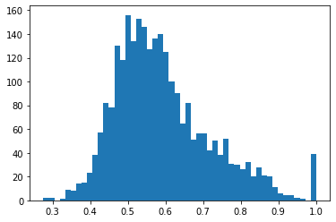

```python
plt.hist(chem_sim_sel['FCFP4_tanimoto_sim'], bins=50)
```

# **3.5 GRAPH CONSTRUCTION**

- In this step the graph is built in python igraph.
- After instantiating the object graph, the nodes are loaded.
- Then the weights are loaded as type1.
- This is to be able to build a multigraph with the interaction edges later on.
- However, the interaction edges finally later on were queried without loading into a multigraph, as this caused some issues in igraph when calculating communities.

```python
G_drugs = ig.Graph()
```

```python
# Setting up nodes
nodes_list_chem_sim = list(nodes_smiles_df['molecule'])

G_drugs.add_vertices(nodes_list_chem_sim)
```

```python
for _, row in chem_sim_sel.iterrows():
    # add an edge with type 1 and the weight from the 'weight' column
    G_drugs.add_edge(row['drug_name_A'], row['drug_name_B'], type=1, weight=row['FCFP4_tanimoto_sim'])
```

```python
G_drugs.summary()
```

```
'IGRAPH UNW- 1332 2651 -- \n+ attr: name (v), type (e), weight (e)'
```

```python
weights_chem_sim = G_drugs.es.select(type=1)['weight']
len(G_drugs.es.select(type=1)['weight'])
```

```
2651
```

# **3.6 COMMUNITY DETECTION**

- Once the graph has been initialized and loaded, the Louvain community algorithm is applied in order to detect different communities based on chemical similarity.
- Since the number of communities is large the print-out of all of them has been deactivated in this notebook, but later on a selection of the most important ones is printed out.
- A random seed is set in order to get reproducible results run over run.
- A visualization of the graph is performed using "graphopt" option in igraph.
- 3 specific communities are highlighted for presentation purposes to locate them in the graph, but deactivated here for simplicity.

# **3.6.A LOUVAIN**

```python
import random
random.seed(42)

# Run community detection algorithm
communities_orig_louvain = G_drugs.community_multilevel(weights=G_drugs.es.select(type=1)['weight'], return_levels=False)

# communities_orig_louvain = communities_orig_louvain.as_clustering(2)

modularity_score_louvain = G_drugs.modularity(communities_orig_louvain.membership)
```

```python
#print(communities_orig_louvain)
#print(modularity_score_louvain)
```

```python
# Get community sizes
community_sizes = communities_orig_louvain.sizes()

# Sort community sizes in descending order
sorted_sizes = sorted(community_sizes, reverse=True)
#print(sorted_sizes)

# Get indices of 10 largest communities
largest_communities = [sorted_sizes[3]] + [sorted_sizes[10]] + [sorted_sizes[11]]
largest_community_indices = [i for i, size in enumerate(community_sizes) if size in largest_communities]
#print(largest_communities)

# Create a list of labels for each vertex in the graph
vertex_labels = ['' for i in range(G_drugs.vcount())]

# Set the label for the vertices in the 10 largest communities
for i in largest_community_indices:
    members = communities_orig_louvain[i]
    for j in members:
        vertex_labels[j] = '#{}'.format(i+1)
```

```python
from igraph import plot
import numpy as np
import random

random.seed(42)

ig.plot(communities_orig_louvain,
        layout='graphopt',
        vertex_size=7,
        edge_color='black',
        bbox=(0, 0, 800, 800),
        weights=G_drugs.es.select(type=1)['weight'],
        # vertex_label=vertex_labels
       ) #, vertex_color=colors)
```

[figure not shown]

- In the next code some of the characteristics of the graph are stored in different lists.
- Also some scoring and metrics
- All this was used to set an adequate threshold for the product of Tanimoto similarities (above) in order to have a good compromise in the communities detected.

```python
list_comm_louvain = []
list_comm_mols_louvain = []
list_comm_smiles_louvain = []
list_comm_size_louvain = []
for zz in communities_orig_louvain:
    list_comm_louvain.append(zz)
    list_indiv_louvain = []
    list_indiv_smiles_louvain = []
    for ww in zz:
        #print(ww)
        list_indiv_louvain.append(nodes_list_chem_sim[ww])
        list_indiv_smiles_louvain.append(nodes_smiles_df['smiles'][nodes_smiles_df['molecule']==nodes_list_chem_sim[ww]].iloc[0])

    list_comm_mols_louvain.append(list_indiv_louvain)
    list_comm_smiles_louvain.append(list_indiv_smiles_louvain)
    list_comm_size_louvain.append(len(list_indiv_louvain))
#list_comm_size_louvain
```

```python
# Number of communities with size greater than a varying threshold
print(modularity_score_louvain)
print(np.max(list_comm_size_louvain))
print(len(np.array(list_comm_size_louvain)[(np.array(list_comm_size_louvain))>5]))
print(len(np.array(list_comm_size_louvain)[(np.array(list_comm_size_louvain))>2]))
print(len(np.array(list_comm_size_louvain)[(np.array(list_comm_size_louvain))==1]))
```

```
0.9102185733489027
54
39
82
432
```

```python
################# RESULTS OF COMMUNITY BASED ON DIFFERENT THRESHOLDS #############
# threshold = 0.0010 -> 0.5638 -> max = 238, size>5,2,1 = 12, 18, 123
# threshold = 0.0030 -> 0.8223 -> max = 111, size>5,2,1 = 27, 52, 225
# threshold = 0.0040 -> 0.8629 -> max = 67, size>5,2,1 = 30, 62, 273
# threshold = 0.0050 -> 0.8865 -> max = 63, size>5,2,1 = 33, 71, 338
# threshold = 0.0060 -> 0.9007 -> max = 59, size>5,2,1 = 37, 75, 383
# threshold = 0.0070 -> 0.9081 -> max = 60, size>5,2,1 = 38, 77, 405
# threshold = 0.0080 -> 0.9XXX -> max = 54, size>5,2,1 = 39, 82, 432
# threshold = 0.0100 -> 0.9155 -> max = 54, size>5,2,1 = 36, 91, 476
# threshold = 0.0150 -> 0.9298 -> max = 49, size>5,2,1 = 35, 89, 533
# threshold = 0.0500 -> 0.9620 -> max = 27, size>5,2,1 = 21, 79, 724
```

- Finally the communities that are identified are stored in the nodes dataframe in order to query conveniently later on.
- A new column called "comm" is created and contains the communities coding to which a specific node belongs to.

```python
# Informing communities to nodes

nodes_smiles_df_comm = nodes_smiles_df.copy()
nodes_smiles_df_comm['comm'] = communities_orig_louvain.membership
nodes_smiles_df_comm
```

|  | molecule | smiles | DDInterID | Drug | Drug_original | topical | nasal | ophthalmic | oral | parenteral | ... | H03_-_THYROID_THERAPY | B03_-_ANTIANEMIC_PREPARATIONS | D09_-_MEDICATED_DRESSINGS | D03_-_PREPARATIONS_FOR_TREATMENT_OF_WOUNDS_AND_ULCERS | D02_-_EMOLLIENTS_AND_PROTECTIVES | J07_-_VACCINES | A09_-_DIGESTIVES,_INCL._ENZYMES | V06_-_GENERAL_NUTRIENTS | H04_-_PANCREATIC_HORMONES | comm |
| --- | --- | --- | --- | --- | --- | --- | --- | --- | --- | --- | --- | --- | --- | --- | --- | --- | --- | --- | --- | --- | --- |
| 0 | Dexamethasone | C[C@@H]1C[C@H]2[C@@H]3CCC4=CC(=O)C=C[C@]4(C)[C... | DDInter513 | Dexamethasone | Dexamethasone | True | False | False | True | True | ... | 0 | 0 | 0 | 0 | 0 | 0 | 0 | 0 | 0 | 0 |
| 1 | Ivacaftor | CC(C)(C)c1cc(C(C)(C)C)c(NC(=O)c2c[nH]c3ccccc3c... | DDInter997 | Ivacaftor | Ivacaftor | False | False | False | True | 0 | ... | 0 | 0 | 0 | 0 | 0 | 0 | 0 | 0 | 0 | 1 |
| 2 | Lamivudine | Nc1ccn([C@@H]2CS[C@H](CO)O2)c(=O)n1 | DDInter1019 | Lamivudine | Lamivudine | False | False | False | True | 0 | ... | 0 | 0 | 0 | 0 | 0 | 0 | 0 | 0 | 0 | 2 |
| 3 | Betamethasone | C[C@H]1C[C@H]2[C@@H]3CCC4=CC(=O)C=C[C@]4(C)[C@... | DDInter195 | Betamethasone | Betamethasone | True | False | False | True | 0 | ... | 0 | 0 | 0 | 0 | 0 | 0 | 0 | 0 | 0 | 0 |
| 4 | Zidovudine | Cc1cn([C@H]2C[C@H](N=[N+]=[N-])[C@@H](CO)O2)c(... | DDInter1961 | Zidovudine | Zidovudine | False | False | False | True | True | ... | 0 | 0 | 0 | 0 | 0 | 0 | 0 | 0 | 0 | 2 |
| ... | ... | ... | ... | ... | ... | ... | ... | ... | ... | ... | ... | ... | ... | ... | ... | ... | ... | ... | ... | ... | ... |
| 1327 | Simethicone | CC(C)(C)[SiH2]O[Si](C)(C)O[SiH2]C(C)(C)C | DDInter1674 | Simethicone | Simethicone | False | False | False | True | 0 | ... | 0 | 0 | 0 | 0 | 0 | 0 | 0 | 0 | 0 | 580 |
| 1328 | Icatibant | N=C(N)NCCC[C@@H](N)C(=O)N[C@@H](CCCNC(=N)N)C(=... | DDInter902 | Icatibant | Icatibant | False | False | False | 0 | True | ... | 0 | 0 | 0 | 0 | 0 | 0 | 0 | 0 | 0 | 30 |
| 1329 | Chondroitin sulfate | CC(=O)N[C@@H]1[C@@H](COC[C@@H]2O[C@H](C(=O)O)[... | DDInter371 | Chondroitin sulfate | Chondroitin sulfate | False | False | False | 0 | 0 | ... | 0 | 0 | 0 | 0 | 0 | 0 | 0 | 0 | 0 | 581 |
| 1330 | Glucosamine | N[C@H]1C(O)O[C@H](CO)[C@@H](O)[C@@H]1O | DDInter829 | Glucosamine | Glucosamine | False | False | False | 0 | 0 | ... | 0 | 0 | 0 | 0 | 0 | 0 | 0 | 0 | 0 | 83 |
| 1331 | Pyrophosphoric acid | O=P(O)(O)OP(=O)(O)O | DDInter1551 | Pyrophosphoric acid | Pyrophosphoric acid | False | False | False | 0 | 0 | ... | 0 | 0 | 0 | 0 | 0 | 0 | 0 | 0 | 0 | 582 |

1332 rows × 121 columns

# **3.7 COMMUNITY CHARACTERISTICS**

- Once the communities have been identified, the characteristics of both the nodes that compose that community as well as the type of interactions those nodes of that community have with others is analyzed

### NODE INFORMATION:MAIN ATC ANALYSIS

- With the following code some examples of identified communities are printed out.
- The communities that have more than 5 drugs as well as a clear ATC that represents the group (more than 50%) is printed out.
- Note the coherent molecules inside each group, having similar names, indicating likely similar chemical structures.
- Therefore, seems that the communities based on chemical structures similarities is working correctly!

```python
list_df_comm = []
idx_big_comm = []
for zz in range(len(list_comm_louvain)):

    if len(list_comm_louvain[zz]) >=5:
        idx_big_comm.append(zz)
        totalsum = nodes_smiles_df[list(nodes_smiles_df.columns)[32:]].iloc[list_comm_louvain[zz]].sum().sum()
        max_val = np.max(round(nodes_smiles_df[list(nodes_smiles_df.columns)[32:]].iloc[list_comm_louvain[zz]].sum().sort_values(ascending=False)[0:5]/totalsum*100,1))
        if max_val >=50:
            #print(list_comm_louvain[zz])
            print("\n")
            print("\n")
            print("COMMUNITY #: ", zz)
            print("Number of drugs: ", len(list_comm_mols_louvain[zz]))
            print(list_comm_mols_louvain[zz])
            #print(nodes_smiles_df[list(nodes_smiles_df.columns)[32:]].iloc[list_comm_louvain[zz]].sum().sort_values(ascending=False)[0:5])
            totalsum = nodes_smiles_df[list(nodes_smiles_df.columns)[32:]].iloc[list_comm_louvain[zz]].sum().sum()
            print(round(nodes_smiles_df[list(nodes_smiles_df.columns)[32:]].iloc[list_comm_louvain[zz]].sum().sort_values(ascending=False)[0:5]/totalsum*100,1), "%")
```

```
COMMUNITY #:  3
Number of drugs:  11
['Astemizole', 'Droperidol', 'Pimozide', 'Trazodone', 'Ziprasidone', 'Aripiprazole', 'Brexpiprazole', 'Cariprazine', 'Flibanserin', 'Nefazodone', 'Vilazodone']
N05_-_PSYCHOLEPTICS                      54.5
N06_-_PSYCHOANALEPTICS                   27.3
R06_-_ANTIHISTAMINES_FOR_SYSTEMIC_USE     9.1
G02_-_OTHER_GYNECOLOGICALS                9.1
R01_-_NASAL_PREPARATIONS                  0.0
dtype: float64 %




COMMUNITY #:  4
Number of drugs:  6
['Caffeine', 'Pentoxifylline', 'Theophylline', 'Dyphylline', 'Aminophylline', 'Oxtriphylline']
R03_-_DRUGS_FOR_OBSTRUCTIVE_AIRWAY_DISEASES    57.1
C04_-_PERIPHERAL_VASODILATORS                  14.3
D11_-_OTHER_DERMATOLOGICAL_PREPARATIONS        14.3
N06_-_PSYCHOANALEPTICS                         14.3
A06_-_DRUGS_FOR_CONSTIPATION                    0.0
dtype: float64 %




COMMUNITY #:  7
Number of drugs:  10
['Lidocaine', 'Ropinirole', 'Bupivacaine', 'Levobupivacaine', 'Mepivacaine', 'Prilocaine', 'Ropivacaine', 'Tocainide', 'Etidocaine', 'Articaine']
N01_-_ANESTHETICS          53.3
S02_-_OTOLOGICALS           6.7
C01_-_CARDIAC_THERAPY       6.7
S01_-_OPHTHALMOLOGICALS     6.7
C05_-_VASOPROTECTIVES       6.7
dtype: float64 %




COMMUNITY #:  22
```

[output cut: 318 more lines]

```
G03_-_SEX_HORMONES_AND_MODULATORS_OF_THE_GENITAL_SYSTEM             0.0
dtype: float64 %




COMMUNITY #:  378
Number of drugs:  7
['Calcitriol', 'Paricalcitol', 'Cholecalciferol', 'Calcifediol', 'Dihydrotachysterol', 'Ergocalciferol', 'Doxercalciferol']
A11_-_VITAMINS                                                    57.1
H05_-_CALCIUM_HOMEOSTASIS                                         28.6
D05_-_ANTIPSORIATICS                                              14.3
R01_-_NASAL_PREPARATIONS                                           0.0
M09_-_OTHER_DRUGS_FOR_DISORDERS_OF_THE_MUSCULO-SKELETAL_SYSTEM     0.0
dtype: float64 %
```

### EDGE INFORMATION: MAJOR INTERACTIONS ANALYSIS

- For edge information, we have focused on analyzing and assigning the average degree for major interactions to each community.
- After preparing the corresponding edges dataframes, the final dataframe of edges is queried in order to calculate the average degree for major interactions for the communities printed out in previous step.
- Note that with both we have a very good descriptor of each community, with ATC and interaction information.

```python
nodes_smiles_df_comm.head(3)

def rename_column_A(col_name):
    return col_name + '_A'

def rename_column_B(col_name):
    return col_name + '_B'

# Use the rename method with the function
nodes_smiles_df_comm_A = nodes_smiles_df_comm.rename(columns=rename_column_A)
nodes_smiles_df_comm_B = nodes_smiles_df_comm.rename(columns=rename_column_B)
```

```python
edges_df_sim_mirror = edges_df_sim.copy()
edges_df_sim_mirror['Drug_A'] = edges_df_sim['Drug_B']
edges_df_sim_mirror['DDInterID_A'] = edges_df_sim['DDInterID_B']
edges_df_sim_mirror['Drug_B'] = edges_df_sim['Drug_A']
edges_df_sim_mirror['DDInterID_B'] = edges_df_sim['DDInterID_A']
edges_df_sim_dupl = pd.concat([edges_df_sim, edges_df_sim_mirror], axis=0).reset_index()
edges_df_sim_dupl
```

|  | index | DDInterID_A | Drug_A | DDInterID_B | Drug_B | Level | Weight |
| --- | --- | --- | --- | --- | --- | --- | --- |
| 0 | 0 | DDInter513 | Dexamethasone | DDInter582 | Dolutegravir | Minor | 1 |
| 1 | 1 | DDInter997 | Ivacaftor | DDInter582 | Dolutegravir | Minor | 1 |
| 2 | 2 | DDInter1019 | Lamivudine | DDInter1123 | Mannitol | Moderate | 2 |
| 3 | 3 | DDInter195 | Betamethasone | DDInter1961 | Zidovudine | Moderate | 2 |
| 4 | 4 | DDInter1961 | Zidovudine | DDInter246 | Budesonide | Moderate | 2 |
| ... | ... | ... | ... | ... | ... | ... | ... |
| 320465 | 160230 | DDInter805 | gamma-Aminobutyric acid | DDInter856 | Heparin | Unknown | 2 |
| 320466 | 160231 | DDInter805 | gamma-Aminobutyric acid | DDInter1683 | Sodium bicarbonate | Unknown | 2 |
| 320467 | 160232 | DDInter62 | Ambrisentan | DDInter908 | Iloprost | Unknown | 2 |
| 320468 | 160233 | DDInter1942 | Vitamin D | DDInter1951 | Warfarin | Unknown | 2 |
| 320469 | 160234 | DDInter1942 | Vitamin D | DDInter1683 | Sodium bicarbonate | Unknown | 2 |

320470 rows × 7 columns

```python
m_edges_df = edges_df_sim_dupl.merge(nodes_smiles_df_comm_A,
                                left_on="DDInterID_A",
                                right_on="DDInterID_A",
                                how='inner')

m_edges_df = m_edges_df.merge(nodes_smiles_df_comm_B,
                                left_on="DDInterID_B",
                                right_on="DDInterID_B",
                                how='inner')

m_edges_df
```

|  | index | DDInterID_A | Drug_A_x | DDInterID_B | Drug_B_x | Level | Weight | molecule_A | smiles_A | Drug_A_y | ... | H03_-_THYROID_THERAPY_B | B03_-_ANTIANEMIC_PREPARATIONS_B | D09_-_MEDICATED_DRESSINGS_B | D03_-_PREPARATIONS_FOR_TREATMENT_OF_WOUNDS_AND_ULCERS_B | D02_-_EMOLLIENTS_AND_PROTECTIVES_B | J07_-_VACCINES_B | A09_-_DIGESTIVES,_INCL._ENZYMES_B | V06_-_GENERAL_NUTRIENTS_B | H04_-_PANCREATIC_HORMONES_B | comm_B |
| --- | --- | --- | --- | --- | --- | --- | --- | --- | --- | --- | --- | --- | --- | --- | --- | --- | --- | --- | --- | --- | --- |
| 0 | 0 | DDInter513 | Dexamethasone | DDInter582 | Dolutegravir | Minor | 1 | Dexamethasone | C[C@@H]1C[C@H]2[C@@H]3CCC4=CC(=O)C=C[C@]4(C)[C... | Dexamethasone | ... | 0 | 0 | 0 | 0 | 0 | 0 | 0 | 0 | 0 | 416 |
| 1 | 1 | DDInter997 | Ivacaftor | DDInter582 | Dolutegravir | Minor | 1 | Ivacaftor | CC(C)(C)c1cc(C(C)(C)C)c(NC(=O)c2c[nH]c3ccccc3c... | Ivacaftor | ... | 0 | 0 | 0 | 0 | 0 | 0 | 0 | 0 | 0 | 416 |
| 2 | 30568 | DDInter743 | Fluconazole | DDInter582 | Dolutegravir | Minor | 1 | Fluconazole | OC(Cn1cncn1)(Cn1cncn1)c1ccc(F)cc1F | Fluconazole | ... | 0 | 0 | 0 | 0 | 0 | 0 | 0 | 0 | 0 | 416 |
| 3 | 115294 | DDInter1881 | Troglitazone | DDInter582 | Dolutegravir | Minor | 1 | Troglitazone | Cc1c(C)c2c(c(C)c1O)CCC(C)(COc1ccc(CC3SC(=O)NC3... | Troglitazone | ... | 0 | 0 | 0 | 0 | 0 | 0 | 0 | 0 | 0 | 416 |
| 4 | 115290 | DDInter1164 | Metformin | DDInter582 | Dolutegravir | Moderate | 2 | Metformin | CN(C)C(=N)NC(=N)N | Metformin | ... | 0 | 0 | 0 | 0 | 0 | 0 | 0 | 0 | 0 | 416 |
| ... | ... | ... | ... | ... | ... | ... | ... | ... | ... | ... | ... | ... | ... | ... | ... | ... | ... | ... | ... | ... | ... |
| 212475 | 56894 | DDInter1719 | Sugammadex | DDInter1310 | Norelgestromin | Major | 3 | Sugammadex | O=C(O)CCSC[C@H]1O[C@@H]2O[C@H]3[C@H](O)[C@@H](... | Sugammadex | ... | 0 | 0 | 0 | 0 | 0 | 0 | 0 | 0 | 0 | 0 |
| 212476 | 56783 | DDInter1914 | Valrubicin | DDInter862 | Hexaminolevulinate | Major | 3 | Valrubicin | CCCCC(=O)OCC(=O)[C@]1(O)Cc2c(O)c3c(c(O)c2[C@@H... | Valrubicin | ... | 0 | 0 | 0 | 0 | 0 | 0 | 0 | 0 | 0 | 573 |
| 212477 | 156105 | DDInter661 | Erdafitinib | DDInter1688 | Sodium glycerophosphate | Major | 3 | Erdafitinib | COc1cc(OC)cc(N(CCNC(C)C)c2ccc3ncc(-c4cnn(C)c4)... | Erdafitinib | ... | 0 | 0 | 0 | 0 | 0 | 0 | 0 | 0 | 0 | 545 |
| 212478 | 38539 | DDInter1081 | Lithium carbonate | DDInter955 | Iodine | Moderate | 2 | Lithium carbonate | O=C([O-])[O-].[Li+].[Li+] | Lithium carbonate | ... | 0 | 0 | 0 | 0 | 0 | 0 | 0 | 0 | 0 | 430 |
| 212479 | 41156 | DDInter194 | Beta carotene | DDInter1107 | Lutein | Minor | 1 | Beta carotene | CC1=C(/C=C/C(C)=C/C=C/C(C)=C/C=C/C=C(C)/C=C/C=... | Beta carotene | ... | 0 | 0 | 0 | 0 | 0 | 0 | 0 | 0 | 0 | 431 |

212480 rows × 247 columns

```python
m_edges_df_major = m_edges_df[m_edges_df['Level']=='Major'].copy()
m_edges_df_major
```

|  | index | DDInterID_A | Drug_A_x | DDInterID_B | Drug_B_x | Level | Weight | molecule_A | smiles_A | Drug_A_y | ... | H03_-_THYROID_THERAPY_B | B03_-_ANTIANEMIC_PREPARATIONS_B | D09_-_MEDICATED_DRESSINGS_B | D03_-_PREPARATIONS_FOR_TREATMENT_OF_WOUNDS_AND_ULCERS_B | D02_-_EMOLLIENTS_AND_PROTECTIVES_B | J07_-_VACCINES_B | A09_-_DIGESTIVES,_INCL._ENZYMES_B | V06_-_GENERAL_NUTRIENTS_B | H04_-_PANCREATIC_HORMONES_B | comm_B |
| --- | --- | --- | --- | --- | --- | --- | --- | --- | --- | --- | --- | --- | --- | --- | --- | --- | --- | --- | --- | --- | --- |
| 13 | 30571 | DDInter1120 | Magnesium sulfate | DDInter582 | Dolutegravir | Major | 3 | Magnesium sulfate | O.O.O.O.O.O.O.O=S(=O)([O-])[O-].[Mg+2] | Magnesium sulfate | ... | 0 | 0 | 0 | 0 | 0 | 0 | 0 | 0 | 0 | 416 |
| 18 | 58873 | DDInter107 | Apalutamide | DDInter582 | Dolutegravir | Major | 3 | Apalutamide | CNC(=O)c1ccc(N2C(=S)N(c3cnc(C#N)c(C(F)(F)F)c3)... | Apalutamide | ... | 0 | 0 | 0 | 0 | 0 | 0 | 0 | 0 | 0 | 416 |
| 30 | 115293 | DDInter1717 | Sucralfate | DDInter582 | Dolutegravir | Major | 3 | Sucralfate | O=S(=O)(OC[C@H]1O[C@@H](O[C@]2(COS(=O)(=O)O[Al... | Sucralfate | ... | 0 | 0 | 0 | 0 | 0 | 0 | 0 | 0 | 0 | 416 |
| 34 | 152815 | DDInter1683 | Sodium bicarbonate | DDInter582 | Dolutegravir | Major | 3 | Sodium bicarbonate | O=C([O-])O.[Na+] | Sodium bicarbonate | ... | 0 | 0 | 0 | 0 | 0 | 0 | 0 | 0 | 0 | 416 |
| 35 | 30564 | DDInter276 | Calcium gluconate | DDInter582 | Dolutegravir | Major | 3 | Calcium gluconate | O=C([O-])[C@H](O)[C@@H](O)[C@H](O)[C@H](O)CO.O... | Calcium gluconate | ... | 0 | 0 | 0 | 0 | 0 | 0 | 0 | 0 | 0 | 416 |
| ... | ... | ... | ... | ... | ... | ... | ... | ... | ... | ... | ... | ... | ... | ... | ... | ... | ... | ... | ... | ... | ... |
| 212464 | 130830 | DDInter1348 | Orlistat | DDInter1869 | Triheptanoin | Major | 3 | Orlistat | CCCCCCCCCCC[C@@H](C[C@@H]1OC(=O)[C@H]1CCCCCC)O... | Orlistat | ... | 0 | 0 | 0 | 0 | 0 | 0 | 0 | 0 | 0 | 404 |
| 212474 | 51430 | DDInter1306 | Nitrous acid | DDInter123 | Articaine | Major | 3 | Nitrous acid | O=NO | Nitrous acid | ... | 0 | 0 | 0 | 0 | 0 | 0 | 0 | 0 | 0 | 7 |
| 212475 | 56894 | DDInter1719 | Sugammadex | DDInter1310 | Norelgestromin | Major | 3 | Sugammadex | O=C(O)CCSC[C@H]1O[C@@H]2O[C@H]3[C@H](O)[C@@H](... | Sugammadex | ... | 0 | 0 | 0 | 0 | 0 | 0 | 0 | 0 | 0 | 0 |
| 212476 | 56783 | DDInter1914 | Valrubicin | DDInter862 | Hexaminolevulinate | Major | 3 | Valrubicin | CCCCC(=O)OCC(=O)[C@]1(O)Cc2c(O)c3c(c(O)c2[C@@H... | Valrubicin | ... | 0 | 0 | 0 | 0 | 0 | 0 | 0 | 0 | 0 | 573 |
| 212477 | 156105 | DDInter661 | Erdafitinib | DDInter1688 | Sodium glycerophosphate | Major | 3 | Erdafitinib | COc1cc(OC)cc(N(CCNC(C)C)c2ccc3ncc(-c4cnn(C)c4)... | Erdafitinib | ... | 0 | 0 | 0 | 0 | 0 | 0 | 0 | 0 | 0 | 545 |

35914 rows × 247 columns

```python
avg_degree_comm = []
for xyz in idx_big_comm:
    avg_degree_ind = round(m_edges_df_major[(m_edges_df_major['comm_A']==xyz)&
                                           (m_edges_df_major['comm_B']!=xyz)].shape[0]/len(list_comm_louvain[xyz]), 1)
    print("AVG MAJOR INTERACTION DEGREE OF COMMUNITY", xyz, ": ", avg_degree_ind)
    avg_degree_comm.append(avg_degree_ind)
```

```
AVG MAJOR INTERACTION DEGREE OF COMMUNITY 0 :  18.1
AVG MAJOR INTERACTION DEGREE OF COMMUNITY 2 :  14.5
AVG MAJOR INTERACTION DEGREE OF COMMUNITY 3 :  53.7
AVG MAJOR INTERACTION DEGREE OF COMMUNITY 4 :  16.7
AVG MAJOR INTERACTION DEGREE OF COMMUNITY 5 :  32.5
AVG MAJOR INTERACTION DEGREE OF COMMUNITY 7 :  2.5
AVG MAJOR INTERACTION DEGREE OF COMMUNITY 8 :  25.1
AVG MAJOR INTERACTION DEGREE OF COMMUNITY 11 :  10.7
AVG MAJOR INTERACTION DEGREE OF COMMUNITY 12 :  33.3
AVG MAJOR INTERACTION DEGREE OF COMMUNITY 13 :  38.9
AVG MAJOR INTERACTION DEGREE OF COMMUNITY 14 :  16.9
AVG MAJOR INTERACTION DEGREE OF COMMUNITY 19 :  34.7
AVG MAJOR INTERACTION DEGREE OF COMMUNITY 20 :  15.3
AVG MAJOR INTERACTION DEGREE OF COMMUNITY 22 :  16.8
AVG MAJOR INTERACTION DEGREE OF COMMUNITY 23 :  17.2
AVG MAJOR INTERACTION DEGREE OF COMMUNITY 27 :  86.8
AVG MAJOR INTERACTION DEGREE OF COMMUNITY 28 :  5.5
AVG MAJOR INTERACTION DEGREE OF COMMUNITY 30 :  20.6
AVG MAJOR INTERACTION DEGREE OF COMMUNITY 35 :  4.8
AVG MAJOR INTERACTION DEGREE OF COMMUNITY 43 :  9.2
AVG MAJOR INTERACTION DEGREE OF COMMUNITY 51 :  18.1
AVG MAJOR INTERACTION DEGREE OF COMMUNITY 78 :  10.4
AVG MAJOR INTERACTION DEGREE OF COMMUNITY 83 :  0.2
AVG MAJOR INTERACTION DEGREE OF COMMUNITY 88 :  8.6
AVG MAJOR INTERACTION DEGREE OF COMMUNITY 90 :  79.8
AVG MAJOR INTERACTION DEGREE OF COMMUNITY 91 :  7.9
AVG MAJOR INTERACTION DEGREE OF COMMUNITY 92 :  6.0
AVG MAJOR INTERACTION DEGREE OF COMMUNITY 93 :  7.2
AVG MAJOR INTERACTION DEGREE OF COMMUNITY 108 :  34.8
AVG MAJOR INTERACTION DEGREE OF COMMUNITY 111 :  110.6
AVG MAJOR INTERACTION DEGREE OF COMMUNITY 112 :  3.4
AVG MAJOR INTERACTION DEGREE OF COMMUNITY 115 :  61.5
AVG MAJOR INTERACTION DEGREE OF COMMUNITY 117 :  53.0
AVG MAJOR INTERACTION DEGREE OF COMMUNITY 127 :  6.8
AVG MAJOR INTERACTION DEGREE OF COMMUNITY 139 :  78.0
AVG MAJOR INTERACTION DEGREE OF COMMUNITY 147 :  20.4
AVG MAJOR INTERACTION DEGREE OF COMMUNITY 149 :  6.6
AVG MAJOR INTERACTION DEGREE OF COMMUNITY 172 :  16.0
AVG MAJOR INTERACTION DEGREE OF COMMUNITY 195 :  6.0
AVG MAJOR INTERACTION DEGREE OF COMMUNITY 206 :  5.4
AVG MAJOR INTERACTION DEGREE OF COMMUNITY 215 :  1.0
AVG MAJOR INTERACTION DEGREE OF COMMUNITY 224 :  15.0
AVG MAJOR INTERACTION DEGREE OF COMMUNITY 225 :  10.6
AVG MAJOR INTERACTION DEGREE OF COMMUNITY 228 :  29.3
AVG MAJOR INTERACTION DEGREE OF COMMUNITY 239 :  6.0
AVG MAJOR INTERACTION DEGREE OF COMMUNITY 254 :  38.6
AVG MAJOR INTERACTION DEGREE OF COMMUNITY 362 :  113.3
AVG MAJOR INTERACTION DEGREE OF COMMUNITY 378 :  1.6
```

# **3.8 ATC & MAJOR INTERACTION PREDICTION TOOL**

- Finally, in this step a prediction for a new drug - molecule that is NOT contained in the previous dataset is performed.
- The idea is to create a new node for the new molecule, calculate all the edges as chemical similarities between this new molecule and all existing ones in the dataset, and create the communities to see to which one it belongs to.
- Then, assign the properties of the community it belongs to, to the new molecule.
- This way we can assign the most likely ATC that will treat as well as the average degree of major interactions (and also the typical major interactions that it will have).

### Steps 0 and 1:

- Below are some examples from FDA website on recently approved molecules.
- These molecules are NOT contained in our dataset.
- They are meant to test the chemical similarity graph.
- One can activate or deactivate any of the below ones, but one at a time.
- Example 1 (active to run):
- new_drug_name = 'Daridorexant'
- new_mol_smiles = 'COc1ccc(-n2nccn2)c(C(=O)N2CCC[C@@]2(C)c2nc3c(C)c(Cl)ccc3[nH]2)c1'
- new_idx = len(nodes_smiles_df)
- Example 2 (active to run):
- new_drug_name = 'Abrocitinib'
- new_mol_smiles = 'CCCS(=O)(=O)N[C@H]1CC@@Hc2ncnc3[nH]ccc23)C1'
- new_idx = len(nodes_smiles_df)
- Example 3 (active to run):
- new_drug_name = 'GANAXOLONE'
- new_mol_smiles = 'CC(=O)[C@H]1CC[C@H]2[C@@H]3CC[C@H]4CC@(O)CC[C@]4(C)[C@H]3CC[C@]12C'
- new_idx = len(nodes_smiles_df)

```python
# Active example being run:
new_drug_name = 'Terlipressin'
new_mol_smiles = 'NCCCC[C@H](NC(=O)[C@@H]1CCCN1C(=O)[C@@H]1CSSC[C@H](NC(=O)CNC(=O)CNC(=O)CN)C(=O)N[C@@H](Cc2ccc(O)cc2)C(=O)N[C@@H](Cc2ccccc2)C(=O)N[C@@H](CCC(N)=O)C(=O)N[C@@H](CC(N)=O)C(=O)N1)C(=O)NCC(N)=O'
new_idx = len(nodes_smiles_df)
```

- Below the previously calculated chemical similarities in another notebook is imported.
- Also a new dataframe containing the smiles of the new molecule and all the previous ones in the dataset as pairwise combinations is created. This is to be filled out in next step when calculating the chemical similarities.

```python
#################################################################################
chem_sim_ext = pd.read_csv(r'C:\Users\Javier\IE Students\Term 3 - Data Dynamos - Documentos\General\Social Network Analysis\drugs\Javier\final\FINAL_EDGES_SIMILARITY_vF.csv')
chem_sim_ext['chem_sim_PROD'] = chem_sim_ext['FCFP4_tanimoto_sim'] * chem_sim_ext['BPF_tanimoto_sim'] * chem_sim_ext['BTF_tanimoto_sim'] \
                         * chem_sim_ext['PATH_tanimoto_sim'] * chem_sim_ext['AP_tanimoto_sim'] * chem_sim_ext['ECFP4_tanimoto_sim']
chem_sim_ext['chem_sim_PROD'] = chem_sim_ext['chem_sim_PROD'] / (np.max(chem_sim_ext['chem_sim_PROD']))
chem_sim_ext = chem_sim_ext.drop("Unnamed: 0", axis=1)

#################################################################################
nodes_smiles_df_ext = nodes_smiles_df.copy()
nodes_smiles_df_ext.head(3)

#################################################################################
new_chem_sim = pd.DataFrame(columns = chem_sim_ext.columns)
new_chem_sim['drug_name_B'] = list(nodes_smiles_df_ext['molecule'])
new_chem_sim['smiles_B'] = list(nodes_smiles_df_ext['smiles'])
new_chem_sim['smiles_B.1'] = list(nodes_smiles_df_ext['smiles'])
new_chem_sim['ddinter_code_B'] = list(nodes_smiles_df_ext['DDInterID'])

new_chem_sim['drug_name_A'] = new_drug_name
new_chem_sim['smiles_A'] = new_mol_smiles

new_chem_sim.head(5)
```

|  | drug_name_A | drug_name_B | smiles_A | smiles_B | ddinter_code_A | smiles_B.1 | ddinter_code_B | FCFP4_tanimoto_sim | BPF_tanimoto_sim | BTF_tanimoto_sim | PATH_tanimoto_sim | AP_tanimoto_sim | ECFP4_tanimoto_sim | chem_sim_PROD |
| --- | --- | --- | --- | --- | --- | --- | --- | --- | --- | --- | --- | --- | --- | --- |
| 0 | Terlipressin | Dexamethasone | NCCCC[C@H](NC(=O)[C@@H]1CCCN1C(=O)[C@@H]1CSSC[... | C[C@@H]1C[C@H]2[C@@H]3CCC4=CC(=O)C=C[C@]4(C)[C... | NaN | C[C@@H]1C[C@H]2[C@@H]3CCC4=CC(=O)C=C[C@]4(C)[C... | DDInter513 | NaN | NaN | NaN | NaN | NaN | NaN | NaN |
| 1 | Terlipressin | Ivacaftor | NCCCC[C@H](NC(=O)[C@@H]1CCCN1C(=O)[C@@H]1CSSC[... | CC(C)(C)c1cc(C(C)(C)C)c(NC(=O)c2c[nH]c3ccccc3c... | NaN | CC(C)(C)c1cc(C(C)(C)C)c(NC(=O)c2c[nH]c3ccccc3c... | DDInter997 | NaN | NaN | NaN | NaN | NaN | NaN | NaN |
| 2 | Terlipressin | Lamivudine | NCCCC[C@H](NC(=O)[C@@H]1CCCN1C(=O)[C@@H]1CSSC[... | Nc1ccn([C@@H]2CS[C@H](CO)O2)c(=O)n1 | NaN | Nc1ccn([C@@H]2CS[C@H](CO)O2)c(=O)n1 | DDInter1019 | NaN | NaN | NaN | NaN | NaN | NaN | NaN |
| 3 | Terlipressin | Betamethasone | NCCCC[C@H](NC(=O)[C@@H]1CCCN1C(=O)[C@@H]1CSSC[... | C[C@H]1C[C@H]2[C@@H]3CCC4=CC(=O)C=C[C@]4(C)[C@... | NaN | C[C@H]1C[C@H]2[C@@H]3CCC4=CC(=O)C=C[C@]4(C)[C@... | DDInter195 | NaN | NaN | NaN | NaN | NaN | NaN | NaN |
| 4 | Terlipressin | Zidovudine | NCCCC[C@H](NC(=O)[C@@H]1CCCN1C(=O)[C@@H]1CSSC[... | Cc1cn([C@H]2C[C@H](N=[N+]=[N-])[C@@H](CO)O2)c(... | NaN | Cc1cn([C@H]2C[C@H](N=[N+]=[N-])[C@@H](CO)O2)c(... | DDInter1961 | NaN | NaN | NaN | NaN | NaN | NaN | NaN |

### Steps 2 and 3:

```python
import guacamol
from guacamol.common_scoring_functions import TanimotoScoringFunction

import warnings
warnings.filterwarnings('ignore')

final_df5 = new_chem_sim.copy()

final_df5['BPF_tanimoto_sim'] = 0.0
listcount = np.linspace(0,900000,241)
count=0
for zz in range(final_df5.shape[0]):
    mol1 = final_df5['smiles_A'][zz]
    mol2 = final_df5['smiles_B'][zz]
    tanimoto_func = TanimotoScoringFunction(target=mol1, fp_type='BPF')
    final_df5['BPF_tanimoto_sim'][zz] = tanimoto_func.score(mol2)
    count = count +1
    if float(count) in listcount: print(count)

final_df5['BTF_tanimoto_sim'] = 0.0
listcount = np.linspace(0,900000,241)
count=0
for zz in range(final_df5.shape[0]):
    mol1 = final_df5['smiles_A'][zz]
    mol2 = final_df5['smiles_B'][zz]
    tanimoto_func = TanimotoScoringFunction(target=mol1, fp_type='BTF')
    final_df5['BTF_tanimoto_sim'][zz] = tanimoto_func.score(mol2)
    count = count +1
    if float(count) in listcount: print(count)

final_df5['PATH_tanimoto_sim'] = 0.0
listcount = np.linspace(0,900000,241)
count=0
for zz in range(final_df5.shape[0]):
    mol1 = final_df5['smiles_A'][zz]
    mol2 = final_df5['smiles_B'][zz]
    tanimoto_func = TanimotoScoringFunction(target=mol1, fp_type='PATH')
    final_df5['PATH_tanimoto_sim'][zz] = tanimoto_func.score(mol2)
    count = count +1
    if float(count) in listcount: print(count)

final_df5['AP_tanimoto_sim'] = 0.0
listcount = np.linspace(0,900000,241)
count=0
for zz in range(final_df5.shape[0]):
    mol1 = final_df5['smiles_A'][zz]
    mol2 = final_df5['smiles_B'][zz]
    tanimoto_func = TanimotoScoringFunction(target=mol1, fp_type='AP')
    final_df5['AP_tanimoto_sim'][zz] = tanimoto_func.score(mol2)
    count = count +1
    if float(count) in listcount: print(count)

final_df5['ECFP4_tanimoto_sim'] = 0.0
listcount = np.linspace(0,900000,241)
count=0
for zz in range(final_df5.shape[0]):
    mol1 = final_df5['smiles_A'][zz]
    mol2 = final_df5['smiles_B'][zz]
    tanimoto_func = TanimotoScoringFunction(target=mol1, fp_type='ECFP4')
    final_df5['ECFP4_tanimoto_sim'][zz] = tanimoto_func.score(mol2)
    count = count +1
    if float(count) in listcount: print(count)

final_df5['FCFP4_tanimoto_sim'] = 0.0
listcount = np.linspace(0,900000,241)
count=0
for zz in range(final_df5.shape[0]):
    mol1 = final_df5['smiles_A'][zz]
    mol2 = final_df5['smiles_B'][zz]
    tanimoto_func = TanimotoScoringFunction(target=mol1, fp_type='ECFP4')
    final_df5['FCFP4_tanimoto_sim'][zz] = tanimoto_func.score(mol2)
    count = count +1
    if float(count) in listcount: print(count)
new_chem_sim = final_df5.copy()


new_chem_sim['chem_sim_PROD'] = new_chem_sim['FCFP4_tanimoto_sim'] * new_chem_sim['BPF_tanimoto_sim'] * new_chem_sim['BTF_tanimoto_sim'] \
                         * new_chem_sim['PATH_tanimoto_sim'] * new_chem_sim['AP_tanimoto_sim'] * new_chem_sim['ECFP4_tanimoto_sim']

new_chem_sim
```

|  | drug_name_A | drug_name_B | smiles_A | smiles_B | ddinter_code_A | smiles_B.1 | ddinter_code_B | FCFP4_tanimoto_sim | BPF_tanimoto_sim | BTF_tanimoto_sim | PATH_tanimoto_sim | AP_tanimoto_sim | ECFP4_tanimoto_sim | chem_sim_PROD |
| --- | --- | --- | --- | --- | --- | --- | --- | --- | --- | --- | --- | --- | --- | --- |
| 0 | Terlipressin | Dexamethasone | NCCCC[C@H](NC(=O)[C@@H]1CCCN1C(=O)[C@@H]1CSSC[... | C[C@@H]1C[C@H]2[C@@H]3CCC4=CC(=O)C=C[C@]4(C)[C... | NaN | C[C@@H]1C[C@H]2[C@@H]3CCC4=CC(=O)C=C[C@]4(C)[C... | DDInter513 | 0.072664 | 0.073409 | 0.206522 | 0.252865 | 0.058494 | 0.072664 | 1.184032e-06 |
| 1 | Terlipressin | Ivacaftor | NCCCC[C@H](NC(=O)[C@@H]1CCCN1C(=O)[C@@H]1CSSC[... | CC(C)(C)c1cc(C(C)(C)C)c(NC(=O)c2c[nH]c3ccccc3c... | NaN | CC(C)(C)c1cc(C(C)(C)C)c(NC(=O)c2c[nH]c3ccccc3c... | DDInter997 | 0.106007 | 0.106596 | 0.269231 | 0.306383 | 0.060375 | 0.106007 | 5.965692e-06 |
| 2 | Terlipressin | Lamivudine | NCCCC[C@H](NC(=O)[C@@H]1CCCN1C(=O)[C@@H]1CSSC[... | Nc1ccn([C@@H]2CS[C@H](CO)O2)c(=O)n1 | NaN | Nc1ccn([C@@H]2CS[C@H](CO)O2)c(=O)n1 | DDInter1019 | 0.061303 | 0.024533 | 0.077922 | 0.235481 | 0.022573 | 0.061303 | 3.818770e-08 |
| 3 | Terlipressin | Betamethasone | NCCCC[C@H](NC(=O)[C@@H]1CCCN1C(=O)[C@@H]1CSSC[... | C[C@H]1C[C@H]2[C@@H]3CCC4=CC(=O)C=C[C@]4(C)[C@... | NaN | C[C@H]1C[C@H]2[C@@H]3CCC4=CC(=O)C=C[C@]4(C)[C@... | DDInter195 | 0.072664 | 0.073409 | 0.206522 | 0.252865 | 0.058494 | 0.072664 | 1.184032e-06 |
| 4 | Terlipressin | Zidovudine | NCCCC[C@H](NC(=O)[C@@H]1CCCN1C(=O)[C@@H]1CSSC[... | Cc1cn([C@H]2C[C@H](N=[N+]=[N-])[C@@H](CO)O2)c(... | NaN | Cc1cn([C@H]2C[C@H](N=[N+]=[N-])[C@@H](CO)O2)c(... | DDInter1961 | 0.059041 | 0.039167 | 0.093750 | 0.299855 | 0.024550 | 0.059041 | 9.422178e-08 |
| ... | ... | ... | ... | ... | ... | ... | ... | ... | ... | ... | ... | ... | ... | ... |
| 1327 | Terlipressin | Simethicone | NCCCC[C@H](NC(=O)[C@@H]1CCCN1C(=O)[C@@H]1CSSC[... | CC(C)(C)[SiH2]O[Si](C)(C)O[SiH2]C(C)(C)C | NaN | CC(C)(C)[SiH2]O[Si](C)(C)O[SiH2]C(C)(C)C | DDInter1674 | 0.000000 | 0.027972 | 0.000000 | 0.051054 | 0.000000 | 0.000000 | 0.000000e+00 |
| 1328 | Terlipressin | Icatibant | NCCCC[C@H](NC(=O)[C@@H]1CCCN1C(=O)[C@@H]1CSSC[... | N=C(N)NCCC[C@@H](N)C(=O)N[C@@H](CCCNC(=N)N)C(=... | NaN | N=C(N)NCCC[C@@H](N)C(=O)N[C@@H](CCCNC(=N)N)C(=... | DDInter902 | 0.292105 | 0.487576 | 0.422727 | 0.541514 | 0.534989 | 0.292105 | 5.094894e-03 |
| 1329 | Terlipressin | Chondroitin sulfate | NCCCC[C@H](NC(=O)[C@@H]1CCCN1C(=O)[C@@H]1CSSC[... | CC(=O)N[C@@H]1[C@@H](COC[C@@H]2O[C@H](C(=O)O)[... | NaN | CC(=O)N[C@@H]1[C@@H](COC[C@@H]2O[C@H](C(=O)O)[... | DDInter371 | 0.078947 | 0.083225 | 0.134078 | 0.306802 | 0.094256 | 0.078947 | 2.011200e-06 |
| 1330 | Terlipressin | Glucosamine | NCCCC[C@H](NC(=O)[C@@H]1CCCN1C(=O)[C@@H]1CSSC[... | N[C@H]1C(O)O[C@H](CO)[C@@H](O)[C@@H]1O | NaN | N[C@H]1C(O)O[C@H](CO)[C@@H](O)[C@@H]1O | DDInter829 | 0.031008 | 0.008599 | 0.025641 | 0.160898 | 0.005102 | 0.031008 | 1.740312e-10 |
| 1331 | Terlipressin | Pyrophosphoric acid | NCCCC[C@H](NC(=O)[C@@H]1CCCN1C(=O)[C@@H]1CSSC[... | O=P(O)(O)OP(=O)(O)O | NaN | O=P(O)(O)OP(=O)(O)O | DDInter1551 | 0.011858 | 0.000833 | 0.000000 | 0.030058 | 0.000000 | 0.011858 | 0.000000e+00 |

1332 rows × 14 columns

```python
chem_sim_ext = pd.read_csv(r'C:\Users\Javier\IE Students\Term 3 - Data Dynamos - Documentos\General\Social Network Analysis\drugs\Javier\final\FINAL_EDGES_SIMILARITY_vF.csv')
chem_sim_ext['chem_sim_PROD'] = chem_sim_ext['FCFP4_tanimoto_sim'] * chem_sim_ext['BPF_tanimoto_sim'] * chem_sim_ext['BTF_tanimoto_sim'] \
                         * chem_sim_ext['PATH_tanimoto_sim'] * chem_sim_ext['AP_tanimoto_sim'] * chem_sim_ext['ECFP4_tanimoto_sim']

chem_sim_ext = chem_sim_ext.drop("Unnamed: 0", axis=1)
chem_sim_ext
```

|  | drug_name_A | drug_name_B | smiles_A | smiles_B | ddinter_code_A | smiles_B.1 | ddinter_code_B | FCFP4_tanimoto_sim | BPF_tanimoto_sim | BTF_tanimoto_sim | PATH_tanimoto_sim | AP_tanimoto_sim | ECFP4_tanimoto_sim | chem_sim_PROD |
| --- | --- | --- | --- | --- | --- | --- | --- | --- | --- | --- | --- | --- | --- | --- |
| 0 | Tedizolid | Amobarbital | Cn1nnc(-c2ccc(-c3ccc(N4C[C@H](CO)OC4=O)cc3F)cn... | CCC1(CCC(C)C)C(=O)NC(=O)NC1=O | DDInter1752 | CCC1(CCC(C)C)C(=O)NC(=O)NC1=O | DDInter81 | 0.091743 | 0.157248 | 0.115385 | 0.162574 | 0.044444 | 0.062500 | 7.517195e-07 |
| 1 | Trioxsalen | Pimecrolimus | Cc1cc2cc3c(C)cc(=O)oc3c(C)c2o1 | CC[C@@H]1/C=C(\C)C[C@H](C)C[C@H](OC)[C@H]2O[C@... | DDInter1877 | CC[C@@H]1/C=C(\C)C[C@H](C)C[C@H](OC)[C@H]2O[C@... | DDInter1468 | 0.020513 | 0.086196 | 0.195312 | 0.234818 | 0.038929 | 0.075676 | 2.388948e-07 |
| 2 | Linagliptin | Telotristat ethyl | CC#CCn1c(N2CCC[C@@H](N)C2)nc2c1c(=O)n(Cc1nc(C)... | CCOC(=O)[C@@H](N)Cc1ccc(-c2cc(O[C@H](c3ccc(Cl)... | DDInter1070 | CCOC(=O)[C@@H](N)Cc1ccc(-c2cc(O[C@H](c3ccc(Cl)... | DDInter1760 | 0.242604 | 0.393110 | 0.284553 | 0.527853 | 0.178155 | 0.153846 | 3.926194e-04 |
| 3 | Argatroban | Telbivudine | CC1CNc2c(cccc2S(=O)(=O)N[C@@H](CCCNC(=N)N)C(=O... | Cc1cn([C@@H]2C[C@@H](O)[C@H](CO)O2)c(=O)[nH]c1=O | DDInter117 | Cc1cn([C@@H]2C[C@@H](O)[C@H](CO)O2)c(=O)[nH]c1=O | DDInter1757 | 0.126984 | 0.124615 | 0.149425 | 0.329435 | 0.093443 | 0.126984 | 9.242916e-06 |
| 4 | Bethanechol | Methenamine | CC(C[N+](C)(C)C)OC(N)=O | C1N2CN3CN1CN(C2)C3 | DDInter199 | C1N2CN3CN1CN(C2)C3 | DDInter1169 | 0.117647 | 0.176471 | 0.000000 | 0.049689 | 0.000000 | 0.000000 | 0.000000e+00 |
| ... | ... | ... | ... | ... | ... | ... | ... | ... | ... | ... | ... | ... | ... | ... |
| 886441 | Cisapride | Histrelin | COc1cc(N)c(Cl)cc1C(=O)NC1CCN(CCCOc2ccc(F)cc2)C... | CCNC(=O)[C@@H]1CCCN1C(=O)[C@H](CCCNC(=N)N)NC(=... | DDInter385 | CCNC(=O)[C@@H]1CCCN1C(=O)[C@H](CCCNC(=N)N)NC(=... | DDInter864 | 0.124611 | 0.103230 | 0.169154 | 0.367839 | 0.104387 | 0.107362 | 8.970139e-06 |
| 886442 | Cisatracurium | Nitisinone | COc1ccc(C[C@@H]2c3cc(OC)c(OC)cc3CC[N@+]2(C)CCC... | O=C1CCCC(=O)C1C(=O)c1ccc(C(F)(F)F)cc1[N+](=O)[O-] | DDInter386 | O=C1CCCC(=O)C1C(=O)c1ccc(C(F)(F)F)cc1[N+](=O)[O-] | DDInter1300 | 0.152074 | 0.096573 | 0.152866 | 0.273667 | 0.073625 | 0.091703 | 4.148130e-06 |
| 886443 | Paclitaxel | Norepinephrine | CC(=O)O[C@H]1C(=O)[C@@]2(C)[C@H]([C@H](OC(=O)c... | NC[C@H](O)c1ccc(O)c(O)c1 | DDInter1377 | NC[C@H](O)c1ccc(O)c(O)c1 | DDInter1311 | 0.091398 | 0.025681 | 0.055901 | 0.143238 | 0.027699 | 0.074074 | 3.856171e-08 |
| 886444 | Lamotrigine | Imatinib | Nc1nnc(-c2cccc(Cl)c2Cl)c(N)n1 | Cc1ccc(NC(=O)c2ccc(CN3CCN(C)CC3)cc2)cc1Nc1nccc... | DDInter1020 | Cc1ccc(NC(=O)c2ccc(CN3CCN(C)CC3)cc2)cc1Nc1nccc... | DDInter909 | 0.160305 | 0.116477 | 0.186047 | 0.276961 | 0.111954 | 0.117647 | 1.267218e-05 |
| 886445 | Larotrectinib | Sodium sulfate | O=C(Nc1cnn2ccc(N3CCC[C@@H]3c3cc(F)ccc3F)nc12)N... | O=S(=O)([O-])[O-].[Na+].[Na+] | DDInter1026 | O=S(=O)([O-])[O-].[Na+].[Na+] | DDInter1693 | 0.041237 | 0.000000 | 0.000000 | 0.006126 | 0.000000 | 0.010000 | 0.000000e+00 |

886446 rows × 14 columns

```python
chem_sim_new = pd.concat([chem_sim_ext, new_chem_sim], axis=0)
chem_sim_new
```

|  | drug_name_A | drug_name_B | smiles_A | smiles_B | ddinter_code_A | smiles_B.1 | ddinter_code_B | FCFP4_tanimoto_sim | BPF_tanimoto_sim | BTF_tanimoto_sim | PATH_tanimoto_sim | AP_tanimoto_sim | ECFP4_tanimoto_sim | chem_sim_PROD |
| --- | --- | --- | --- | --- | --- | --- | --- | --- | --- | --- | --- | --- | --- | --- |
| 0 | Tedizolid | Amobarbital | Cn1nnc(-c2ccc(-c3ccc(N4C[C@H](CO)OC4=O)cc3F)cn... | CCC1(CCC(C)C)C(=O)NC(=O)NC1=O | DDInter1752 | CCC1(CCC(C)C)C(=O)NC(=O)NC1=O | DDInter81 | 0.091743 | 0.157248 | 0.115385 | 0.162574 | 0.044444 | 0.062500 | 7.517195e-07 |
| 1 | Trioxsalen | Pimecrolimus | Cc1cc2cc3c(C)cc(=O)oc3c(C)c2o1 | CC[C@@H]1/C=C(\C)C[C@H](C)C[C@H](OC)[C@H]2O[C@... | DDInter1877 | CC[C@@H]1/C=C(\C)C[C@H](C)C[C@H](OC)[C@H]2O[C@... | DDInter1468 | 0.020513 | 0.086196 | 0.195312 | 0.234818 | 0.038929 | 0.075676 | 2.388948e-07 |
| 2 | Linagliptin | Telotristat ethyl | CC#CCn1c(N2CCC[C@@H](N)C2)nc2c1c(=O)n(Cc1nc(C)... | CCOC(=O)[C@@H](N)Cc1ccc(-c2cc(O[C@H](c3ccc(Cl)... | DDInter1070 | CCOC(=O)[C@@H](N)Cc1ccc(-c2cc(O[C@H](c3ccc(Cl)... | DDInter1760 | 0.242604 | 0.393110 | 0.284553 | 0.527853 | 0.178155 | 0.153846 | 3.926194e-04 |
| 3 | Argatroban | Telbivudine | CC1CNc2c(cccc2S(=O)(=O)N[C@@H](CCCNC(=N)N)C(=O... | Cc1cn([C@@H]2C[C@@H](O)[C@H](CO)O2)c(=O)[nH]c1=O | DDInter117 | Cc1cn([C@@H]2C[C@@H](O)[C@H](CO)O2)c(=O)[nH]c1=O | DDInter1757 | 0.126984 | 0.124615 | 0.149425 | 0.329435 | 0.093443 | 0.126984 | 9.242916e-06 |
| 4 | Bethanechol | Methenamine | CC(C[N+](C)(C)C)OC(N)=O | C1N2CN3CN1CN(C2)C3 | DDInter199 | C1N2CN3CN1CN(C2)C3 | DDInter1169 | 0.117647 | 0.176471 | 0.000000 | 0.049689 | 0.000000 | 0.000000 | 0.000000e+00 |
| ... | ... | ... | ... | ... | ... | ... | ... | ... | ... | ... | ... | ... | ... | ... |
| 1327 | Terlipressin | Simethicone | NCCCC[C@H](NC(=O)[C@@H]1CCCN1C(=O)[C@@H]1CSSC[... | CC(C)(C)[SiH2]O[Si](C)(C)O[SiH2]C(C)(C)C | NaN | CC(C)(C)[SiH2]O[Si](C)(C)O[SiH2]C(C)(C)C | DDInter1674 | 0.000000 | 0.027972 | 0.000000 | 0.051054 | 0.000000 | 0.000000 | 0.000000e+00 |
| 1328 | Terlipressin | Icatibant | NCCCC[C@H](NC(=O)[C@@H]1CCCN1C(=O)[C@@H]1CSSC[... | N=C(N)NCCC[C@@H](N)C(=O)N[C@@H](CCCNC(=N)N)C(=... | NaN | N=C(N)NCCC[C@@H](N)C(=O)N[C@@H](CCCNC(=N)N)C(=... | DDInter902 | 0.292105 | 0.487576 | 0.422727 | 0.541514 | 0.534989 | 0.292105 | 5.094894e-03 |
| 1329 | Terlipressin | Chondroitin sulfate | NCCCC[C@H](NC(=O)[C@@H]1CCCN1C(=O)[C@@H]1CSSC[... | CC(=O)N[C@@H]1[C@@H](COC[C@@H]2O[C@H](C(=O)O)[... | NaN | CC(=O)N[C@@H]1[C@@H](COC[C@@H]2O[C@H](C(=O)O)[... | DDInter371 | 0.078947 | 0.083225 | 0.134078 | 0.306802 | 0.094256 | 0.078947 | 2.011200e-06 |
| 1330 | Terlipressin | Glucosamine | NCCCC[C@H](NC(=O)[C@@H]1CCCN1C(=O)[C@@H]1CSSC[... | N[C@H]1C(O)O[C@H](CO)[C@@H](O)[C@@H]1O | NaN | N[C@H]1C(O)O[C@H](CO)[C@@H](O)[C@@H]1O | DDInter829 | 0.031008 | 0.008599 | 0.025641 | 0.160898 | 0.005102 | 0.031008 | 1.740312e-10 |
| 1331 | Terlipressin | Pyrophosphoric acid | NCCCC[C@H](NC(=O)[C@@H]1CCCN1C(=O)[C@@H]1CSSC[... | O=P(O)(O)OP(=O)(O)O | NaN | O=P(O)(O)OP(=O)(O)O | DDInter1551 | 0.011858 | 0.000833 | 0.000000 | 0.030058 | 0.000000 | 0.011858 | 0.000000e+00 |

887778 rows × 14 columns

### Step 4:

- In this step we apply the same threshold as before.
- We end up with more edges than the base case above, corresponding to new edges formed between the new drug and existing drugs.

```python
chem_sim_new['chem_sim_PROD'] = chem_sim_new['chem_sim_PROD'] / (np.max(chem_sim_new['chem_sim_PROD']))
chem_sim_new
```

|  | drug_name_A | drug_name_B | smiles_A | smiles_B | ddinter_code_A | smiles_B.1 | ddinter_code_B | FCFP4_tanimoto_sim | BPF_tanimoto_sim | BTF_tanimoto_sim | PATH_tanimoto_sim | AP_tanimoto_sim | ECFP4_tanimoto_sim | chem_sim_PROD |
| --- | --- | --- | --- | --- | --- | --- | --- | --- | --- | --- | --- | --- | --- | --- |
| 0 | Tedizolid | Amobarbital | Cn1nnc(-c2ccc(-c3ccc(N4C[C@H](CO)OC4=O)cc3F)cn... | CCC1(CCC(C)C)C(=O)NC(=O)NC1=O | DDInter1752 | CCC1(CCC(C)C)C(=O)NC(=O)NC1=O | DDInter81 | 0.091743 | 0.157248 | 0.115385 | 0.162574 | 0.044444 | 0.062500 | 7.517195e-07 |
| 1 | Trioxsalen | Pimecrolimus | Cc1cc2cc3c(C)cc(=O)oc3c(C)c2o1 | CC[C@@H]1/C=C(\C)C[C@H](C)C[C@H](OC)[C@H]2O[C@... | DDInter1877 | CC[C@@H]1/C=C(\C)C[C@H](C)C[C@H](OC)[C@H]2O[C@... | DDInter1468 | 0.020513 | 0.086196 | 0.195312 | 0.234818 | 0.038929 | 0.075676 | 2.388948e-07 |
| 2 | Linagliptin | Telotristat ethyl | CC#CCn1c(N2CCC[C@@H](N)C2)nc2c1c(=O)n(Cc1nc(C)... | CCOC(=O)[C@@H](N)Cc1ccc(-c2cc(O[C@H](c3ccc(Cl)... | DDInter1070 | CCOC(=O)[C@@H](N)Cc1ccc(-c2cc(O[C@H](c3ccc(Cl)... | DDInter1760 | 0.242604 | 0.393110 | 0.284553 | 0.527853 | 0.178155 | 0.153846 | 3.926194e-04 |
| 3 | Argatroban | Telbivudine | CC1CNc2c(cccc2S(=O)(=O)N[C@@H](CCCNC(=N)N)C(=O... | Cc1cn([C@@H]2C[C@@H](O)[C@H](CO)O2)c(=O)[nH]c1=O | DDInter117 | Cc1cn([C@@H]2C[C@@H](O)[C@H](CO)O2)c(=O)[nH]c1=O | DDInter1757 | 0.126984 | 0.124615 | 0.149425 | 0.329435 | 0.093443 | 0.126984 | 9.242916e-06 |
| 4 | Bethanechol | Methenamine | CC(C[N+](C)(C)C)OC(N)=O | C1N2CN3CN1CN(C2)C3 | DDInter199 | C1N2CN3CN1CN(C2)C3 | DDInter1169 | 0.117647 | 0.176471 | 0.000000 | 0.049689 | 0.000000 | 0.000000 | 0.000000e+00 |
| ... | ... | ... | ... | ... | ... | ... | ... | ... | ... | ... | ... | ... | ... | ... |
| 1327 | Terlipressin | Simethicone | NCCCC[C@H](NC(=O)[C@@H]1CCCN1C(=O)[C@@H]1CSSC[... | CC(C)(C)[SiH2]O[Si](C)(C)O[SiH2]C(C)(C)C | NaN | CC(C)(C)[SiH2]O[Si](C)(C)O[SiH2]C(C)(C)C | DDInter1674 | 0.000000 | 0.027972 | 0.000000 | 0.051054 | 0.000000 | 0.000000 | 0.000000e+00 |
| 1328 | Terlipressin | Icatibant | NCCCC[C@H](NC(=O)[C@@H]1CCCN1C(=O)[C@@H]1CSSC[... | N=C(N)NCCC[C@@H](N)C(=O)N[C@@H](CCCNC(=N)N)C(=... | NaN | N=C(N)NCCC[C@@H](N)C(=O)N[C@@H](CCCNC(=N)N)C(=... | DDInter902 | 0.292105 | 0.487576 | 0.422727 | 0.541514 | 0.534989 | 0.292105 | 5.094894e-03 |
| 1329 | Terlipressin | Chondroitin sulfate | NCCCC[C@H](NC(=O)[C@@H]1CCCN1C(=O)[C@@H]1CSSC[... | CC(=O)N[C@@H]1[C@@H](COC[C@@H]2O[C@H](C(=O)O)[... | NaN | CC(=O)N[C@@H]1[C@@H](COC[C@@H]2O[C@H](C(=O)O)[... | DDInter371 | 0.078947 | 0.083225 | 0.134078 | 0.306802 | 0.094256 | 0.078947 | 2.011200e-06 |
| 1330 | Terlipressin | Glucosamine | NCCCC[C@H](NC(=O)[C@@H]1CCCN1C(=O)[C@@H]1CSSC[... | N[C@H]1C(O)O[C@H](CO)[C@@H](O)[C@@H]1O | NaN | N[C@H]1C(O)O[C@H](CO)[C@@H](O)[C@@H]1O | DDInter829 | 0.031008 | 0.008599 | 0.025641 | 0.160898 | 0.005102 | 0.031008 | 1.740312e-10 |
| 1331 | Terlipressin | Pyrophosphoric acid | NCCCC[C@H](NC(=O)[C@@H]1CCCN1C(=O)[C@@H]1CSSC[... | O=P(O)(O)OP(=O)(O)O | NaN | O=P(O)(O)OP(=O)(O)O | DDInter1551 | 0.011858 | 0.000833 | 0.000000 | 0.030058 | 0.000000 | 0.011858 | 0.000000e+00 |

887778 rows × 14 columns

```python
chem_sim_new_sel = chem_sim_new[chem_sim_new['chem_sim_PROD']>0.008].copy() # 0.01 optimum
chem_sim_new_sel
```

|  | drug_name_A | drug_name_B | smiles_A | smiles_B | ddinter_code_A | smiles_B.1 | ddinter_code_B | FCFP4_tanimoto_sim | BPF_tanimoto_sim | BTF_tanimoto_sim | PATH_tanimoto_sim | AP_tanimoto_sim | ECFP4_tanimoto_sim | chem_sim_PROD |
| --- | --- | --- | --- | --- | --- | --- | --- | --- | --- | --- | --- | --- | --- | --- |
| 133 | Promethazine | Mesoridazine | CC(CN1c2ccccc2Sc2ccccc21)N(C)C | CN1CCCCC1CCN1c2ccccc2Sc2ccc([S+](C)[O-])cc21 | DDInter1533 | CN1CCCCC1CCN1c2ccccc2Sc2ccc([S+](C)[O-])cc21 | DDInter1159 | 0.590361 | 0.541916 | 0.719298 | 0.630024 | 0.329016 | 0.375000 | 0.017888 |
| 142 | Hydrocortisone butyrate | Methyltestosterone | CCCC(=O)O[C@]1(C(=O)CO)CC[C@H]2[C@@H]3CCC4=CC(... | C[C@]12CCC(=O)C=C1CC[C@@H]1[C@@H]2CC[C@@]2(C)[... | DDInter888 | C[C@]12CCC(=O)C=C1CC[C@@H]1[C@@H]2CC[C@@]2(C)[... | DDInter1193 | 0.586957 | 0.484009 | 0.662791 | 0.562500 | 0.429175 | 0.460000 | 0.020910 |
| 469 | Clobetasol | Prednisolone | C[C@H]1C[C@H]2[C@@H]3CCC4=CC(=O)C=C[C@]4(C)[C@... | C[C@]12C=CC(=O)C=C1CC[C@@H]1[C@@H]2[C@@H](O)C[... | DDInter402 | C[C@]12C=CC(=O)C=C1CC[C@@H]1[C@@H]2[C@@H](O)C[... | DDInter1513 | 0.659091 | 0.766332 | 0.825581 | 0.706093 | 0.608796 | 0.445545 | 0.079863 |
| 869 | Polythiazide | Trichlormethiazide | CN1C(CSCC(F)(F)F)Nc2cc(Cl)c(S(N)(=O)=O)cc2S1(=... | NS(=O)(=O)c1cc2c(cc1Cl)NC(C(Cl)Cl)NS2(=O)=O | DDInter1490 | NS(=O)(=O)c1cc2c(cc1Cl)NC(C(Cl)Cl)NS2(=O)=O | DDInter1861 | 0.539474 | 0.368715 | 0.406250 | 0.762201 | 0.338028 | 0.444444 | 0.009253 |
| 942 | Oxacillin | Ticarcillin | Cc1onc(-c2ccccc2)c1C(=O)N[C@@H]1C(=O)N2[C@@H]1... | CC1(C)S[C@@H]2[C@H](NC(=O)[C@H](C(=O)O)c3ccsc3... | DDInter1354 | CC1(C)S[C@@H]2[C@H](NC(=O)[C@H](C(=O)O)c3ccsc3... | DDInter1803 | 0.531915 | 0.591549 | 0.657895 | 0.703462 | 0.404301 | 0.440000 | 0.025905 |
| ... | ... | ... | ... | ... | ... | ... | ... | ... | ... | ... | ... | ... | ... | ... |
| 831 | Terlipressin | Triptorelin | NCCCC[C@H](NC(=O)[C@@H]1CCCN1C(=O)[C@@H]1CSSC[... | CC(C)C[C@H](NC(=O)[C@@H](Cc1c[nH]c2ccccc12)NC(... | NaN | CC(C)C[C@H](NC(=O)[C@@H](Cc1c[nH]c2ccccc12)NC(... | DDInter1880 | 0.328042 | 0.628398 | 0.717391 | 0.588283 | 0.581989 | 0.328042 | 0.016609 |
| 1130 | Terlipressin | Lanreotide | NCCCC[C@H](NC(=O)[C@@H]1CCCN1C(=O)[C@@H]1CSSC[... | CC(C)[C@@H]1NC(=O)[C@H](CCCCN)NC(=O)[C@@H](Cc2... | NaN | CC(C)[C@@H]1NC(=O)[C@H](CCCCN)NC(=O)[C@@H](Cc2... | DDInter1021 | 0.433121 | 0.603555 | 0.647059 | 0.634783 | 0.582364 | 0.433121 | 0.027083 |
| 1143 | Terlipressin | Gonadorelin | NCCCC[C@H](NC(=O)[C@@H]1CCCN1C(=O)[C@@H]1CSSC[... | CC(C)C[C@H](NC(=O)CNC(=O)[C@H](Cc1ccc(O)cc1)NC... | NaN | CC(C)C[C@H](NC(=O)CNC(=O)[C@H](Cc1ccc(O)cc1)NC... | DDInter838 | 0.368116 | 0.614166 | 0.773006 | 0.588283 | 0.612419 | 0.368116 | 0.023178 |
| 1197 | Terlipressin | Linaclotide | NCCCC[C@H](NC(=O)[C@@H]1CCCN1C(=O)[C@@H]1CSSC[... | C[C@@H]1NC(=O)[C@@H]2CCCN2C(=O)[C@H](CC(N)=O)N... | NaN | C[C@@H]1NC(=O)[C@@H]2CCCN2C(=O)[C@H](CC(N)=O)N... | DDInter1069 | 0.357143 | 0.598368 | 0.779661 | 0.840535 | 0.600563 | 0.357143 | 0.030038 |
| 1322 | Terlipressin | Bremelanotide | NCCCC[C@H](NC(=O)[C@@H]1CCCN1C(=O)[C@@H]1CSSC[... | CCCC[C@H](NC(C)=O)C(=O)N[C@H]1CC(=O)NCCCC[C@@H... | NaN | CCCC[C@H](NC(C)=O)C(=O)N[C@H]1CC(=O)NCCCC[C@@H... | DDInter227 | 0.410828 | 0.581589 | 0.660377 | 0.547755 | 0.595120 | 0.410828 | 0.021131 |

2668 rows × 14 columns

- Now the new graph is built in the same way as above, just with more edges (more chemical similarities)
- After building it, the Louvain community detection algorithm is run again.
- If the new node is assigned to a community with at least 1 previous node from the dataset, it will be possible to make a prediction for the new molecule regarding ATC and major interactions degree, based on the average of the community it belongs to.

```python
G_drugs_new = ig.Graph()
# Setting up nodes
nodes_list_chem_sim_new = list(nodes_smiles_df['molecule']) + [new_drug_name]

G_drugs_new.add_vertices(nodes_list_chem_sim_new)

for _, row in chem_sim_new_sel.iterrows():
    # add an edge with type 1 and the weight from the 'weight' column
    G_drugs_new.add_edge(row['drug_name_A'], row['drug_name_B'], type=1, weight=row['FCFP4_tanimoto_sim'])

print(G_drugs_new.summary())

weights_chem_sim = G_drugs_new.es.select(type=1)['weight']
len(G_drugs_new.es.select(type=1)['weight'])
```

```
IGRAPH UNW- 1333 2668 --
+ attr: name (v), type (e), weight (e)
```

```
2668
```

```python
import random
random.seed(42)

# Run community detection algorithm
communities_orig_louvain_new = G_drugs_new.community_multilevel(weights=G_drugs_new.es.select(type=1)['weight'], return_levels=False)

# communities_orig_louvain = communities_orig_louvain.as_clustering(2)

modularity_score_louvain_new = G_drugs_new.modularity(communities_orig_louvain_new.membership)
```

```python
list_comm_louvain = []
list_comm_mols_louvain = []
list_comm_smiles_louvain = []
list_comm_size_louvain = []
for zz in communities_orig_louvain_new:
    list_comm_louvain.append(zz)
    list_indiv_louvain = []
    list_indiv_smiles_louvain = []
    for ww in zz:
        #print(ww)
        if ww<1332:
            list_indiv_louvain.append(nodes_list_chem_sim[ww])
            list_indiv_smiles_louvain.append(nodes_smiles_df['smiles'][nodes_smiles_df['molecule']==nodes_list_chem_sim[ww]].iloc[0])

    list_comm_mols_louvain.append(list_indiv_louvain)
    list_comm_smiles_louvain.append(list_indiv_smiles_louvain)
    list_comm_size_louvain.append(len(list_indiv_louvain))
#list_comm_size_louvain
```

- In next cell the community to which the new molecuel (new node) belongs to is shown:

```python
communities_orig_louvain_new.membership[1332]
```

```
30
```

### NODE PREDICTION

- Firstly, the prediction of the node ATC is performed.
- Below the list of the nodes belonging to the same community to which the new molecule belongs also is shown.

```python
list_comm_louvain[communities_orig_louvain_new.membership[1332]]
```

```
[65,
 160,
 228,
 279,
 306,
 313,
 350,
 391,
 401,
 411,
 475,
 593,
 684,
 688,
 689,
 691,
 692,
 704,
 821,
 826,
 831,
 864,
 1067,
 1085,
 1130,
 1143,
 1197,
 1199,
 1239,
 1249,
 1295,
 1309,
 1311,
 1317,
 1322,
 1328,
 1332]
```

- With the following piece of code, a print-out is generated that includes:
  1. Community Number to which it belongs to.
  2. Number of drugs in the base dataset that are in that community (they constitute the basis for the prediction)
  3. List of drugs on that community
  4. List of ATCs that they treat and its frequency (in %)

```python
zz = communities_orig_louvain_new.membership[new_idx]
#totalsum = nodes_smiles_df[list(nodes_smiles_df.columns)[32:]].iloc[list_comm_louvain[zz].remove(new_idx)].sum().sum()
#max_val = np.max(round(nodes_smiles_df[list(nodes_smiles_df.columns)[32:]].iloc[list_comm_louvain[zz].remove(new_idx)].sum().sort_values(ascending=False)[0:5]/totalsum*100,1))
print("\n")
print("\n")
print("COMMUNITY #: ", zz)
print("Number of drugs: ", len(list_comm_mols_louvain[zz]))
if len(list_comm_mols_louvain[zz])>=1:
    print(list_comm_mols_louvain[zz])
    if len(list_comm_louvain[zz])>=2: idx_all = list_comm_louvain[zz].remove(new_idx)
    totalsum = nodes_smiles_df[list(nodes_smiles_df.columns)[32:]].iloc[list_comm_louvain[zz]].sum().sum()
    print(round(nodes_smiles_df[list(nodes_smiles_df.columns)[32:]].iloc[list_comm_louvain[zz]].sum().sort_values(ascending=False)[0:5]/totalsum*100,1), "%")

else: print("No previous data to predict")
```

[output not shown]

### EDGE PREDICTION

- Finally, also the prediction of the average major interaction degree for that community is calculated.
- This value is assigned to the new node (new molecule).

```python
if len(list_comm_mols_louvain[zz])>=1:
    avg_degree_ind = round(m_edges_df_major[(m_edges_df_major['comm_A']==zz)&
                                           (m_edges_df_major['comm_B']!=zz)].shape[0]/len(list_comm_louvain[zz]), 1)
    print("AVG MAJOR INTERACTION DEGREE OF COMMUNITY", zz, ": ", avg_degree_ind)
    avg_degree_comm.append(avg_degree_ind)
else: print("No previous data to predict")
```

```
AVG MAJOR INTERACTION DEGREE OF COMMUNITY 30 :  20.6
```

### SUMMARY DESCRIPTION & PREDICTION:

- It has been shown in this notebook the feasibility of building a chemical similarity network in order to:

  A. Describe the communities within the known dataset in terms of ATCs and major interactions avg degree. B. Predict, based on to which community the new molecule belongs to, the most likely ATC that will treat as well as the major interactions degree that will have. The graph also allows to go deeper and get to individual interactions as needed.